# Sesgo

Javier espinoza

2022-06-12

# ANALISÍS DE SESGO

## Librerias usadas

```r
library(Peptides)
library (seqinr)
library(tidyverse)
library(cluster)
library(factoextra)
library(pheatmap)
library(readxl)
library(stats)
```

# 4 clusters

## Leer archivo fuente, este es un excel, cambie un poco el codigo para usar lo que se

```r
Lista_calculo4 <- read_excel("C:/Users/javeb/Documents/R/TESIS/SESGADOS/CLUSTER_4.xlsx")
View(Lista_calculo4)
```

## Ahora a obtener los descriptores, verlo y guardarlos en un archivo Excel

```r
peptideDescriptors4 <- data.frame(
  Name = unlist(Lista_calculo4$Name),
  sequence = unlist(Lista_calculo4$Sequence),
  aIndex = aIndex(Lista_calculo4$Sequence),
  boman = boman(Lista_calculo4$Sequence),
  charge = charge(Lista_calculo4$Sequence, pH = 7, pKscale = "Sillero"),
  crucianiProperties = do.call(rbind.data.frame, crucianiProperties(Lista_calculo4$Sequence)),
  fasgaiVectors = do.call(rbind.data.frame, fasgaiVectors(Lista_calculo4$Sequence)),
  hydrophobicity = hydrophobicity(Lista_calculo4$Sequence, scale="Kidera"),
  pI = pI(Lista_calculo4$Sequence, pKscale="EMBOSS"),mw = mw(Lista_calculo4$Sequence))
colnames(peptideDescriptors4) <- c('Name','sequence', "aIndex", "Boman", "Charge", paste0('PP', 1:3), paste0('F', 1:6), "Hidrophobicity","pI", "MW")
view(peptideDescriptors4)
Tabla = subset(peptideDescriptors4, select = -c(sequence))
knitr::kable(Tabla, caption = "**Tabla 1.** Descriptores")
```

**Tabla 1.** Descriptores

| Name | aIndex | Boman | Charge | PP1 | PP2 | PP3 | F1 | F2 | F3 | F4 | F5 | F6 | Hidrophobicity | pI | MW |
| --- | --- | --- | --- | --- | --- | --- | --- | --- | --- | --- | --- | --- | --- | --- | --- |
| >Antiox_1 | 103.33333 | 0.5627778 | -1.0538969 | -0.3300000 | -0.4538889 | 0.0927778 | -0.1120556 | 0.0165000 | -0.3827222 | 0.8094444 | 0.1480000 | -0.2091667 | -0.0222222 | 4.258141 | 1805.0177 |
| >Antiox_2 | 37.69231 | 1.9584615 | 1.3324165 | -0.0876923 | -0.3384615 | 0.2761538 | -0.1028462 | -0.4549231 | -0.4346154 | -0.0149231 | 0.0067692 | -0.1303077 | -0.0753846 | 8.564801 | 1421.5558 |
| >Antiox_3 | 14.28571 | 3.9257143 | -4.0497356 | 0.3371429 | -0.4642857 | -0.5614286 | -0.7451429 | 0.2350000 | -0.2124286 | 0.1777143 | 0.5840000 | -1.0128571 | 0.3914286 | 3.331708 | 851.8218 |
| >Antiox_6 | 97.50000 | 0.7975000 | 1.9364036 | -0.1325000 | -0.0993750 | 0.0862500 | -0.0538125 | -0.2690625 | 0.3640000 | 0.2704375 | 0.2588125 | 0.2653125 | -0.0962500 | 9.634027 | 1961.2909 |
| >Antiox_8 | 20.00000 | 2.6960000 | 0.3423275 | 0.2380000 | -0.4880000 | 0.3980000 | -0.1720000 | 0.0892000 | -0.5492000 | -0.1008000 | 0.0434000 | 0.0494000 | 0.2680000 | 7.714355 | 551.5595 |
| >Antiox_9 | 55.71429 | 2.1071429 | 0.9397985 | -0.2414286 | -0.1771429 | 0.0628571 | -0.5312857 | -0.4012857 | 0.0167143 | 0.1278571 | 0.9430000 | 0.2348571 | 0.0342857 | 9.348818 | 829.9542 |
| >Antiox_11 | 84.28571 | -0.1257143 | -0.0690935 | -0.4271429 | -0.4971429 | 0.0985714 | 0.1184286 | 0.0410000 | -0.6315714 | 0.3710000 | 0.5292857 | -0.2300000 | -0.2742857 | 5.922539 | 688.7966 |
| >Antiox_13 | 70.00000 | 3.8142857 | -2.0522868 | 0.3428571 | -0.4142857 | -0.3271429 | -0.6937143 | 0.7477143 | -0.1958571 | 0.4885714 | 0.1398571 | -0.5067143 | 0.6542857 | 3.927560 | 831.8778 |
| >Antiox_14 | 12.50000 | 3.5250000 | -3.0540422 | 0.1912500 | -0.5487500 | -0.3550000 | -0.5213750 | 0.0700000 | -0.4348750 | 0.0118750 | 0.4875000 | -0.7272500 | 0.3462500 | 3.380031 | 905.9318 |
| >Antiox_15 | 65.00000 | 0.3666667 | -1.0601915 | -0.1733333 | -0.3366667 | -0.1100000 | 0.0250000 | -0.9116667 | 0.0521667 | 0.5381667 | -0.6038333 | -0.6028333 | -0.2883333 | 3.749971 | 686.7190 |
| >Antiox_16 | 0.00000 | 4.1466667 | -0.8574335 | 0.2633333 | -0.6666667 | -0.0466667 | -0.5910000 | -0.7340000 | -0.7546667 | -0.1176667 | -0.4576667 | -0.9130000 | 0.3100000 | 5.292276 | 327.2968 |
| >Antiox_18 | 0.00000 | 5.6620000 | -0.8546791 | 0.7220000 | -0.4160000 | -0.0500000 | -0.8672000 | 0.3054000 | -0.2588000 | -0.1390000 | 0.0228000 | -0.2324000 | 0.9180000 | 5.454283 | 628.6396 |
| >Antiox_19 | 127.00000 | -0.6010000 | -0.8574335 | -0.5440000 | -0.5070000 | 0.0360000 | 0.1217000 | -0.4473000 | -0.5040000 | 0.9076000 | 0.1915000 | -0.7162000 | -0.3710000 | 5.292276 | 949.0743 |
| >Antiox_20 | 58.00000 | 1.9420000 | -1.0581935 | -0.0140000 | -0.7560000 | 0.0580000 | -0.6724000 | -0.6830000 | -0.7800000 | 0.6006000 | -0.2902000 | -0.2722000 | 0.2600000 | 3.749973 | 477.4716 |
| >Antiox_21 | 0.00000 | 3.0000000 | -1.0601915 | 0.5400000 | -0.0166667 | -0.4666667 | -0.2133333 | -0.7200000 | 0.9740000 | -0.3776667 | -0.6430000 | -0.3946667 | -0.1033333 | 3.749971 | 459.4558 |
| >Antiox_23 | 110.00000 | 2.9962500 | -3.0518889 | 0.2200000 | -0.4762500 | -0.3887500 | -0.4258750 | 0.4413750 | -0.2206250 | 0.5815000 | 0.0807500 | -0.8075000 | 0.2875000 | 3.424715 | 916.9400 |
| >Antiox_24 | 292.50000 | -1.9875000 | -1.0560402 | -0.4500000 | -0.1325000 | -0.4125000 | 0.6437500 | 1.0450000 | 0.4635000 | 1.1887500 | 0.3250000 | -0.2895000 | -0.4500000 | 3.849974 | 486.6089 |
| >Antiox_25 | 24.37500 | 2.9368750 | -1.8610398 | 0.0368750 | -0.4062500 | -0.0450000 | -0.4478125 | -0.2468125 | -0.3935000 | -0.0433750 | 0.6785000 | -0.2118125 | 0.1493750 | 4.421435 | 1799.9325 |
| >Antiox_26 | 55.71429 | 3.5728571 | 0.1437108 | 0.2028571 | -0.1128571 | 0.0614286 | -0.3172857 | -0.0554286 | 0.1348571 | 0.0510000 | 0.5651429 | 0.0808571 | 0.1900000 | 7.543349 | 900.9896 |
| >Antiox_28 | 0.00000 | -0.6480000 | -0.0591925 | -0.5220000 | -0.0260000 | -0.2460000 | 0.5054000 | -0.4558000 | 0.3848000 | 0.1508000 | -0.3236000 | -0.3592000 | -0.7280000 | 6.099982 | 630.7007 |
| >Antiox_32 | 97.50000 | -0.2725000 | -1.0560402 | -0.4050000 | -0.1075000 | -0.4700000 | 0.1727500 | 0.1927500 | 0.2785000 | 0.4907500 | 1.2047500 | -0.6417500 | -0.5275000 | 3.849974 | 504.5834 |
| >Antiox_34 | 72.50000 | 0.1612500 | 0.9404096 | -0.3812500 | -0.3400000 | 0.1425000 | -0.5760000 | -0.4768750 | -0.2008750 | 0.4083750 | 0.8936250 | 0.1082500 | -0.1487500 | 9.700016 | 860.0209 |
| >Antiox_35 | 78.00000 | -0.8440000 | 0.9404096 | -0.6180000 | -0.3220000 | 0.2160000 | -0.2940000 | 0.0024000 | -0.2030000 | 0.7898000 | -0.2876000 | 0.0868000 | -0.1120000 | 9.700016 | 520.6292 |
| >Antiox_36 | 66.66667 | -1.5200000 | -0.0591925 | -0.9333333 | -0.8400000 | 0.3700000 | 0.0696667 | -0.1923333 | -1.2246667 | 1.3343333 | -0.3296667 | -0.7820000 | -0.2333333 | 6.099982 | 217.2247 |
| >Antiox_37 | 70.00000 | 1.4942857 | 0.9407975 | -0.2728571 | -0.1142857 | 0.0900000 | -0.0671429 | -0.2320000 | 0.0021429 | 0.3212857 | 0.3470000 | -0.0345714 | -0.1257143 | 10.549999 | 826.9534 |
| >Antiox_38 | 40.83333 | 1.0450000 | 0.9407975 | -0.4858333 | -0.5200000 | 0.2333333 | -0.2312500 | -1.0610000 | -0.7300000 | 0.6150833 | 0.6420833 | -0.4115833 | -0.0550000 | 10.549999 | 1107.2344 |
| >Antiox_40 | 0.00000 | 3.4300000 | -0.0659512 | 0.1300000 | -0.2000000 | 0.1300000 | -0.2395000 | -0.2256667 | -0.3216667 | -0.2906667 | -0.3861667 | 0.0555000 | 0.1133333 | 6.232445 | 736.8003 |
| >Antiox_41 | 65.00000 | -0.4950000 | -1.0560402 | -0.5633333 | -0.4050000 | -0.1500000 | 0.0468333 | -0.6111667 | -0.3663333 | 0.7368333 | 0.4315000 | -0.8098333 | -0.4050000 | 3.849974 | 618.6872 |
| >Antiox_43 | 0.00000 | 3.2600000 | 0.9407975 | -0.4425000 | -0.4425000 | 0.4750000 | -0.5115000 | -1.5245000 | -0.8400000 | 0.5005000 | 0.3912500 | -0.1680000 | 0.2000000 | 10.549999 | 385.4232 |
| >Antiox_44 | 83.57143 | 0.4300000 | -0.0560502 | -0.3557143 | -0.1550000 | -0.0814286 | 0.0213571 | -0.1697857 | 0.1147143 | 0.3172143 | 0.4226429 | -0.1179286 | -0.2964286 | 6.410139 | 1646.9090 |

[output cut: 340 more lines]

```r
write.csv2(peptideDescriptors4, "Descriptores4.csv")
```

## Quito primera y segunda fila y exploratorio de datos

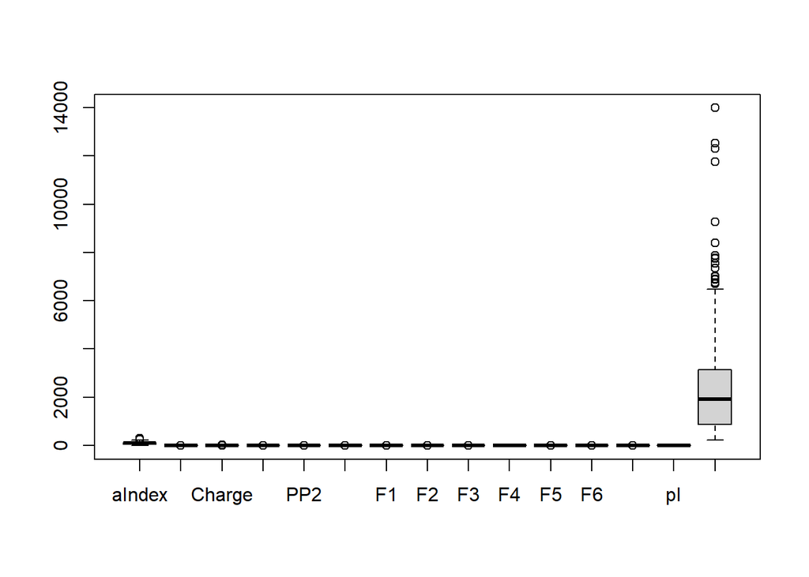

```r
datapep4= subset(peptideDescriptors4, select = -c(Name, sequence))
view(datapep4)
boxplot(datapep4)
```

```r
summary(datapep4)
```

```
##      aIndex           Boman             Charge              PP1
##  Min.   :  0.00   Min.   :-3.2050   Min.   :-7.04703   Min.   :-0.9333
##  1st Qu.: 40.83   1st Qu.:-0.2933   1st Qu.:-0.06019   1st Qu.:-0.4168
##  Median : 85.26   Median : 0.7460   Median : 0.94041   Median :-0.2592
##  Mean   : 87.43   Mean   : 0.9345   Mean   : 1.60250   Mean   :-0.2256
##  3rd Qu.:120.00   3rd Qu.: 1.9491   3rd Qu.: 3.93822   3rd Qu.:-0.0695
##  Max.   :292.50   Max.   : 5.6620   Max.   :10.13897   Max.   : 0.7220
##       PP2               PP3                 F1                 F2
##  Min.   :-0.8400   Min.   :-0.58083   Min.   :-1.35033   Min.   :-1.52450
##  1st Qu.:-0.3983   1st Qu.: 0.01942   1st Qu.:-0.34148   1st Qu.:-0.38612
##  Median :-0.3071   Median : 0.11892   Median :-0.11948   Median :-0.00536
##  Mean   :-0.3001   Mean   : 0.09119   Mean   :-0.14438   Mean   :-0.03270
##  3rd Qu.:-0.2067   3rd Qu.: 0.21338   3rd Qu.: 0.04213   3rd Qu.: 0.28424
##  Max.   : 0.3767   Max.   : 0.47500   Max.   : 0.81000   Max.   : 1.09789
##        F3                  F4                F5                 F6
##  Min.   :-1.224667   Min.   :-0.6240   Min.   :-0.67725   Min.   :-1.20275
##  1st Qu.:-0.375670   1st Qu.: 0.0884   1st Qu.:-0.12145   1st Qu.:-0.21178
##  Median :-0.166611   Median : 0.4243   Median : 0.03227   Median :-0.04059
##  Mean   :-0.159708   Mean   : 0.4188   Mean   : 0.16137   Mean   :-0.06715
##  3rd Qu.: 0.005141   3rd Qu.: 0.7446   3rd Qu.: 0.28275   3rd Qu.: 0.11740
##  Max.   : 1.401000   Max.   : 1.3991   Max.   : 2.29467   Max.   : 1.07767
##  Hidrophobicity           pI               MW
##  Min.   :-1.09500   Min.   : 3.167   Min.   :  217.2
##  1st Qu.:-0.17081   1st Qu.: 6.100   1st Qu.:  864.8
##  Median :-0.01256   Median : 8.171   Median : 1913.4
##  Mean   :-0.01409   Mean   : 8.263   Mean   : 2406.8
##  3rd Qu.: 0.15274   3rd Qu.:10.866   3rd Qu.: 3146.7
##  Max.   : 0.98200   Max.   :13.278   Max.   :13992.9
```

## Normalizar y ver cambios

```r
pepscale4 = scale(datapep4)
summary(pepscale4)
```

```
##      aIndex             Boman             Charge             PP1
##  Min.   :-1.53929   Min.   :-2.5572   Min.   :-2.9987   Min.   :-2.6961
##  1st Qu.:-0.82036   1st Qu.:-0.7585   1st Qu.:-0.5764   1st Qu.:-0.7283
##  Median :-0.03808   Median :-0.1164   Median :-0.2295   Median :-0.1279
##  Mean   : 0.00000   Mean   : 0.0000   Mean   : 0.0000   Mean   : 0.0000
##  3rd Qu.: 0.57348   3rd Qu.: 0.6268   3rd Qu.: 0.8098   3rd Qu.: 0.5946
##  Max.   : 3.61060   Max.   : 2.9204   Max.   : 2.9595   Max.   : 3.6097
##       PP2                PP3                F1                 F2
##  Min.   :-3.10617   Min.   :-3.5825   Min.   :-3.91425   Min.   :-3.12933
##  1st Qu.:-0.56506   1st Qu.:-0.3826   1st Qu.:-0.63975   1st Qu.:-0.74138
##  Median :-0.04007   Median : 0.1478   Median : 0.08082   Median : 0.05734
##  Mean   : 0.00000   Mean   : 0.0000   Mean   : 0.00000   Mean   : 0.00000
##  3rd Qu.: 0.53714   3rd Qu.: 0.6514   3rd Qu.: 0.60537   3rd Qu.: 0.66483
##  Max.   : 3.89359   Max.   : 2.0461   Max.   : 3.09768   Max.   : 2.37161
##        F3                 F4                 F5                F6
##  Min.   :-3.15503   Min.   :-2.41921   Min.   :-1.7578   Min.   :-3.49486
##  1st Qu.:-0.63980   1st Qu.:-0.76655   1st Qu.:-0.5928   1st Qu.:-0.44508
##  Median :-0.02045   Median : 0.01279   Median :-0.2706   Median : 0.08174
##  Mean   : 0.00000   Mean   : 0.00000   Mean   : 0.0000   Mean   : 0.00000
##  3rd Qu.: 0.48838   3rd Qu.: 0.75562   3rd Qu.: 0.2544   3rd Qu.: 0.56798
##  Max.   : 4.62373   Max.   : 2.27415   Max.   : 4.4714   Max.   : 3.52325
##  Hidrophobicity            pI                 MW
##  Min.   :-3.623541   Min.   :-1.83774   Min.   :-1.0733
##  1st Qu.:-0.525368   1st Qu.:-0.77996   1st Qu.:-0.7559
##  Median : 0.005158   Median :-0.03321   Median :-0.2419
##  Mean   : 0.000000   Mean   : 0.00000   Mean   : 0.0000
##  3rd Qu.: 0.559279   3rd Qu.: 0.93861   3rd Qu.: 0.3627
##  Max.   : 3.339229   Max.   : 1.80842   Max.   : 5.6793
```

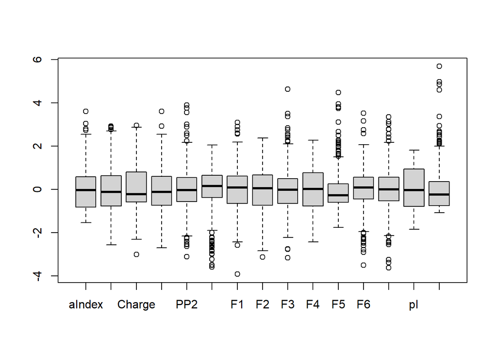

```r
boxplot(pepscale4)
```

## Para escoger el numero de PCAs

```r
stdev4= PCApep4$sdev
pr_var4 = stdev4^2
pr_var4[1:15]
```

[output not shown]

```
##  [1] 4.82044202 3.10545877 2.10766004 1.65275663 1.14183077 0.72221904
##  [7] 0.41278614 0.36988781 0.22870315 0.14548371 0.11746161 0.08522158
## [13] 0.05171699 0.02481411 0.01355763
```

```r
prop_varex4 =pr_var4/sum(pr_var4)
prop_varex4[1:15]
```

```
##  [1] 0.3213628014 0.2070305846 0.1405106693 0.1101837752 0.0761220515
##  [6] 0.0481479357 0.0275190760 0.0246591875 0.0152468769 0.0096989141
## [11] 0.0078307739 0.0056814386 0.0034477996 0.0016542738 0.0009038419
```

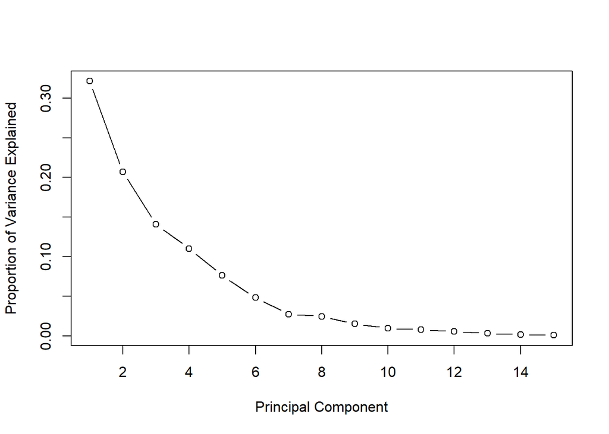

```r
plot(prop_varex4, xlab = "Principal Component",ylab = "Proportion of Variance Explained",type = "b")
```

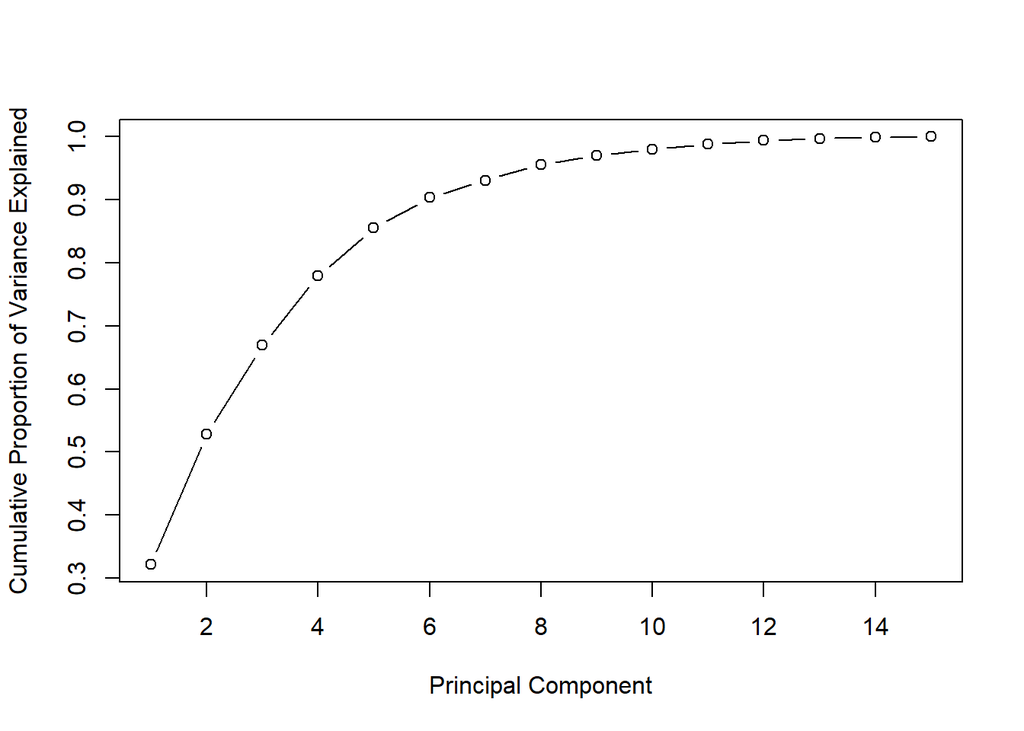

```r
plot(cumsum(prop_varex4), xlab = "Principal Component",ylab = "Cumulative Proportion of Variance Explained",type = "b")
```

## Determinar numero optimo de clusters por medio del metodo de “avarage silhouette”

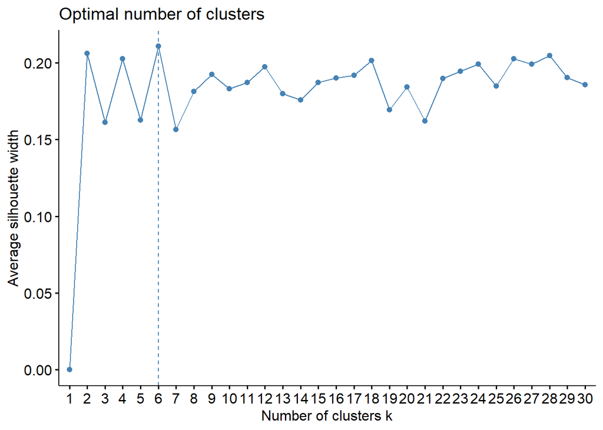

```r
fviz_nbclust(PCApep4$x[ ,1:15],kmeans,method = "silhouette", k.max = 30, iter.max=25)
```

## Graficar heatmap

## Heatmap de 4 clusters

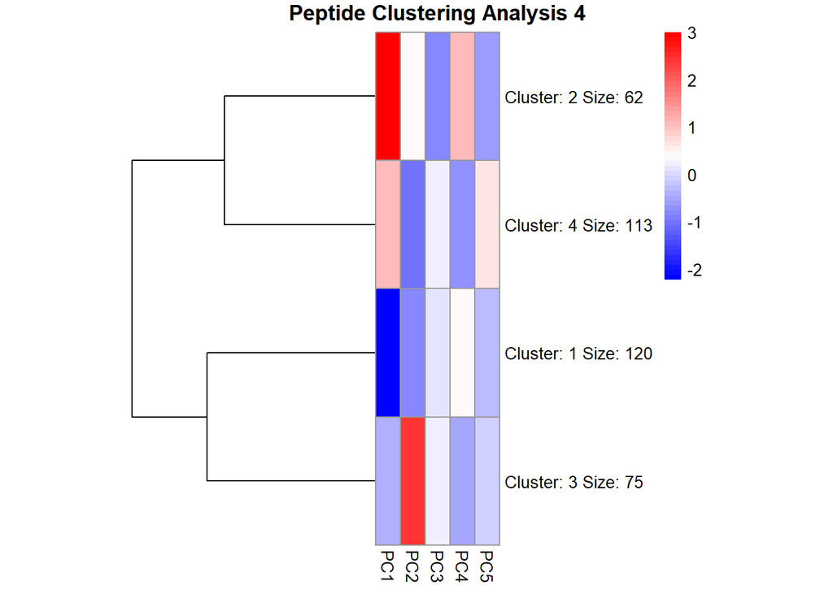

```r
cluster4pep= pheatmap(PCApep4$x[,1:5], kmeans_k = 4,cluster_cols = FALSE, treeheight_row = 150, cellwidth = 15, color = colorRampPalette(c("blue", "white", "red"))(50),main = "Peptide Clustering Analysis 4" )
```

```r
write.csv2 (cluster4pep$kmeans$cluster, file="clustermemberS4pep.csv")
```

# 5 clusters

## Leer archivo fuente, este es un excel, cambie un poco el codigo para usar lo que se

```r
Lista_calculo5 <- read_excel("C:/Users/javeb/Documents/R/TESIS/SESGADOS/CLUSTER_5.xlsx")
View(Lista_calculo5)
```

## Ahora a obtener los descriptores, verlo y guardarlos en un archivo Excel

```r
peptideDescriptors5 <- data.frame(
  Name = unlist(Lista_calculo5$Name),
  sequence = unlist(Lista_calculo5$Sequence),
  aIndex = aIndex(Lista_calculo5$Sequence),
  boman = boman(Lista_calculo5$Sequence),
  charge = charge(Lista_calculo5$Sequence, pH = 7, pKscale = "Sillero"),
  crucianiProperties = do.call(rbind.data.frame, crucianiProperties(Lista_calculo5$Sequence)),
  fasgaiVectors = do.call(rbind.data.frame, fasgaiVectors(Lista_calculo5$Sequence)),
  hydrophobicity = hydrophobicity(Lista_calculo5$Sequence, scale="Kidera"),
  pI = pI(Lista_calculo5$Sequence, pKscale="EMBOSS"),mw = mw(Lista_calculo5$Sequence))
colnames(peptideDescriptors5) <- c('Name','sequence', "aIndex", "Boman", "Charge", paste0('PP', 1:3), paste0('F', 1:6), "Hidrophobicity","pI", "MW")
view(peptideDescriptors5)
Tabla = subset(peptideDescriptors5, select = -c(sequence))
knitr::kable(Tabla, caption = "**Tabla 1.** Descriptores")
```

**Tabla 1.** Descriptores

| Name | aIndex | Boman | Charge | PP1 | PP2 | PP3 | F1 | F2 | F3 | F4 | F5 | F6 | Hidrophobicity | pI | MW |
| --- | --- | --- | --- | --- | --- | --- | --- | --- | --- | --- | --- | --- | --- | --- | --- |
| >Antiox_1 | 103.33333 | 0.5627778 | -1.0538969 | -0.3300000 | -0.4538889 | 0.0927778 | -0.1120556 | 0.0165000 | -0.3827222 | 0.8094444 | 0.1480000 | -0.2091667 | -0.0222222 | 4.258141 | 1805.0177 |
| >Antiox_2 | 37.69231 | 1.9584615 | 1.3324165 | -0.0876923 | -0.3384615 | 0.2761538 | -0.1028462 | -0.4549231 | -0.4346154 | -0.0149231 | 0.0067692 | -0.1303077 | -0.0753846 | 8.564801 | 1421.5558 |
| >Antiox_3 | 14.28571 | 3.9257143 | -4.0497356 | 0.3371429 | -0.4642857 | -0.5614286 | -0.7451429 | 0.2350000 | -0.2124286 | 0.1777143 | 0.5840000 | -1.0128571 | 0.3914286 | 3.331708 | 851.8218 |
| >Antiox_6 | 97.50000 | 0.7975000 | 1.9364036 | -0.1325000 | -0.0993750 | 0.0862500 | -0.0538125 | -0.2690625 | 0.3640000 | 0.2704375 | 0.2588125 | 0.2653125 | -0.0962500 | 9.634027 | 1961.2909 |
| >Antiox_8 | 20.00000 | 2.6960000 | 0.3423275 | 0.2380000 | -0.4880000 | 0.3980000 | -0.1720000 | 0.0892000 | -0.5492000 | -0.1008000 | 0.0434000 | 0.0494000 | 0.2680000 | 7.714355 | 551.5595 |
| >Antiox_9 | 55.71429 | 2.1071429 | 0.9397985 | -0.2414286 | -0.1771429 | 0.0628571 | -0.5312857 | -0.4012857 | 0.0167143 | 0.1278571 | 0.9430000 | 0.2348571 | 0.0342857 | 9.348818 | 829.9542 |
| >Antiox_11 | 84.28571 | -0.1257143 | -0.0690935 | -0.4271429 | -0.4971429 | 0.0985714 | 0.1184286 | 0.0410000 | -0.6315714 | 0.3710000 | 0.5292857 | -0.2300000 | -0.2742857 | 5.922539 | 688.7966 |
| >Antiox_13 | 70.00000 | 3.8142857 | -2.0522868 | 0.3428571 | -0.4142857 | -0.3271429 | -0.6937143 | 0.7477143 | -0.1958571 | 0.4885714 | 0.1398571 | -0.5067143 | 0.6542857 | 3.927560 | 831.8778 |
| >Antiox_14 | 12.50000 | 3.5250000 | -3.0540422 | 0.1912500 | -0.5487500 | -0.3550000 | -0.5213750 | 0.0700000 | -0.4348750 | 0.0118750 | 0.4875000 | -0.7272500 | 0.3462500 | 3.380031 | 905.9318 |
| >Antiox_15 | 65.00000 | 0.3666667 | -1.0601915 | -0.1733333 | -0.3366667 | -0.1100000 | 0.0250000 | -0.9116667 | 0.0521667 | 0.5381667 | -0.6038333 | -0.6028333 | -0.2883333 | 3.749971 | 686.7190 |
| >Antiox_16 | 0.00000 | 4.1466667 | -0.8574335 | 0.2633333 | -0.6666667 | -0.0466667 | -0.5910000 | -0.7340000 | -0.7546667 | -0.1176667 | -0.4576667 | -0.9130000 | 0.3100000 | 5.292276 | 327.2968 |
| >Antiox_18 | 0.00000 | 5.6620000 | -0.8546791 | 0.7220000 | -0.4160000 | -0.0500000 | -0.8672000 | 0.3054000 | -0.2588000 | -0.1390000 | 0.0228000 | -0.2324000 | 0.9180000 | 5.454283 | 628.6396 |
| >Antiox_19 | 127.00000 | -0.6010000 | -0.8574335 | -0.5440000 | -0.5070000 | 0.0360000 | 0.1217000 | -0.4473000 | -0.5040000 | 0.9076000 | 0.1915000 | -0.7162000 | -0.3710000 | 5.292276 | 949.0743 |
| >Antiox_20 | 58.00000 | 1.9420000 | -1.0581935 | -0.0140000 | -0.7560000 | 0.0580000 | -0.6724000 | -0.6830000 | -0.7800000 | 0.6006000 | -0.2902000 | -0.2722000 | 0.2600000 | 3.749973 | 477.4716 |
| >Antiox_21 | 0.00000 | 3.0000000 | -1.0601915 | 0.5400000 | -0.0166667 | -0.4666667 | -0.2133333 | -0.7200000 | 0.9740000 | -0.3776667 | -0.6430000 | -0.3946667 | -0.1033333 | 3.749971 | 459.4558 |
| >Antiox_23 | 110.00000 | 2.9962500 | -3.0518889 | 0.2200000 | -0.4762500 | -0.3887500 | -0.4258750 | 0.4413750 | -0.2206250 | 0.5815000 | 0.0807500 | -0.8075000 | 0.2875000 | 3.424715 | 916.9400 |
| >Antiox_24 | 292.50000 | -1.9875000 | -1.0560402 | -0.4500000 | -0.1325000 | -0.4125000 | 0.6437500 | 1.0450000 | 0.4635000 | 1.1887500 | 0.3250000 | -0.2895000 | -0.4500000 | 3.849974 | 486.6089 |
| >Antiox_25 | 24.37500 | 2.9368750 | -1.8610398 | 0.0368750 | -0.4062500 | -0.0450000 | -0.4478125 | -0.2468125 | -0.3935000 | -0.0433750 | 0.6785000 | -0.2118125 | 0.1493750 | 4.421435 | 1799.9325 |
| >Antiox_26 | 55.71429 | 3.5728571 | 0.1437108 | 0.2028571 | -0.1128571 | 0.0614286 | -0.3172857 | -0.0554286 | 0.1348571 | 0.0510000 | 0.5651429 | 0.0808571 | 0.1900000 | 7.543349 | 900.9896 |
| >Antiox_28 | 0.00000 | -0.6480000 | -0.0591925 | -0.5220000 | -0.0260000 | -0.2460000 | 0.5054000 | -0.4558000 | 0.3848000 | 0.1508000 | -0.3236000 | -0.3592000 | -0.7280000 | 6.099982 | 630.7007 |
| >Antiox_32 | 97.50000 | -0.2725000 | -1.0560402 | -0.4050000 | -0.1075000 | -0.4700000 | 0.1727500 | 0.1927500 | 0.2785000 | 0.4907500 | 1.2047500 | -0.6417500 | -0.5275000 | 3.849974 | 504.5834 |
| >Antiox_34 | 72.50000 | 0.1612500 | 0.9404096 | -0.3812500 | -0.3400000 | 0.1425000 | -0.5760000 | -0.4768750 | -0.2008750 | 0.4083750 | 0.8936250 | 0.1082500 | -0.1487500 | 9.700016 | 860.0209 |
| >Antiox_35 | 78.00000 | -0.8440000 | 0.9404096 | -0.6180000 | -0.3220000 | 0.2160000 | -0.2940000 | 0.0024000 | -0.2030000 | 0.7898000 | -0.2876000 | 0.0868000 | -0.1120000 | 9.700016 | 520.6292 |
| >Antiox_36 | 66.66667 | -1.5200000 | -0.0591925 | -0.9333333 | -0.8400000 | 0.3700000 | 0.0696667 | -0.1923333 | -1.2246667 | 1.3343333 | -0.3296667 | -0.7820000 | -0.2333333 | 6.099982 | 217.2247 |
| >Antiox_37 | 70.00000 | 1.4942857 | 0.9407975 | -0.2728571 | -0.1142857 | 0.0900000 | -0.0671429 | -0.2320000 | 0.0021429 | 0.3212857 | 0.3470000 | -0.0345714 | -0.1257143 | 10.549999 | 826.9534 |
| >Antiox_38 | 40.83333 | 1.0450000 | 0.9407975 | -0.4858333 | -0.5200000 | 0.2333333 | -0.2312500 | -1.0610000 | -0.7300000 | 0.6150833 | 0.6420833 | -0.4115833 | -0.0550000 | 10.549999 | 1107.2344 |
| >Antiox_40 | 0.00000 | 3.4300000 | -0.0659512 | 0.1300000 | -0.2000000 | 0.1300000 | -0.2395000 | -0.2256667 | -0.3216667 | -0.2906667 | -0.3861667 | 0.0555000 | 0.1133333 | 6.232445 | 736.8003 |
| >Antiox_41 | 65.00000 | -0.4950000 | -1.0560402 | -0.5633333 | -0.4050000 | -0.1500000 | 0.0468333 | -0.6111667 | -0.3663333 | 0.7368333 | 0.4315000 | -0.8098333 | -0.4050000 | 3.849974 | 618.6872 |
| >Antiox_43 | 0.00000 | 3.2600000 | 0.9407975 | -0.4425000 | -0.4425000 | 0.4750000 | -0.5115000 | -1.5245000 | -0.8400000 | 0.5005000 | 0.3912500 | -0.1680000 | 0.2000000 | 10.549999 | 385.4232 |
| >Antiox_44 | 83.57143 | 0.4300000 | -0.0560502 | -0.3557143 | -0.1550000 | -0.0814286 | 0.0213571 | -0.1697857 | 0.1147143 | 0.3172143 | 0.4226429 | -0.1179286 | -0.2964286 | 6.410139 | 1646.9090 |

[output cut: 342 more lines]

```r
write.csv2(peptideDescriptors5, "Descriptores5.csv")
```

## Quito primera y segunda fila y exploratorio de datos

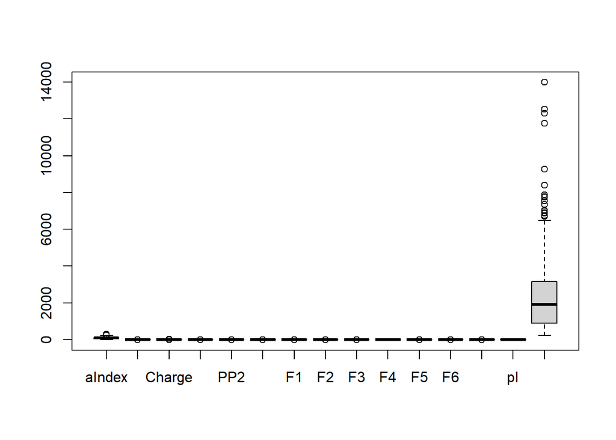

```r
datapep5= subset(peptideDescriptors5, select = -c(Name, sequence))
view(datapep5)
boxplot(datapep5)
```

```r
summary(datapep5)
```

```
##      aIndex           Boman             Charge              PP1
##  Min.   :  0.00   Min.   :-3.2050   Min.   :-7.04703   Min.   :-0.93333
##  1st Qu.: 41.43   1st Qu.:-0.2800   1st Qu.:-0.06019   1st Qu.:-0.41620
##  Median : 85.26   Median : 0.7505   Median : 0.94041   Median :-0.25917
##  Mean   : 87.62   Mean   : 0.9297   Mean   : 1.62353   Mean   :-0.22580
##  3rd Qu.:120.00   3rd Qu.: 1.9444   3rd Qu.: 3.93822   3rd Qu.:-0.07395
##  Max.   :292.50   Max.   : 5.6620   Max.   :10.13897   Max.   : 0.72200
##       PP2               PP3                 F1                 F2
##  Min.   :-0.8400   Min.   :-0.58083   Min.   :-1.35033   Min.   :-1.524500
##  1st Qu.:-0.3983   1st Qu.: 0.01892   1st Qu.:-0.33612   1st Qu.:-0.386895
##  Median :-0.3045   Median : 0.11781   Median :-0.11848   Median :-0.007419
##  Mean   :-0.2962   Mean   : 0.08995   Mean   :-0.14194   Mean   :-0.034523
##  3rd Qu.:-0.2000   3rd Qu.: 0.21109   3rd Qu.: 0.04274   3rd Qu.: 0.283487
##  Max.   : 0.3954   Max.   : 0.47500   Max.   : 0.81000   Max.   : 1.097889
##        F3                 F4                 F5                 F6
##  Min.   :-1.22467   Min.   :-0.62400   Min.   :-0.67725   Min.   :-1.20275
##  1st Qu.:-0.37415   1st Qu.: 0.07983   1st Qu.:-0.11984   1st Qu.:-0.21170
##  Median :-0.16452   Median : 0.42221   Median : 0.03365   Median :-0.03987
##  Mean   :-0.15321   Mean   : 0.41472   Mean   : 0.16594   Mean   :-0.06610
##  3rd Qu.: 0.01031   3rd Qu.: 0.73941   3rd Qu.: 0.28580   3rd Qu.: 0.12043
##  Max.   : 1.40100   Max.   : 1.39913   Max.   : 2.29467   Max.   : 1.07767
##  Hidrophobicity           pI               MW
##  Min.   :-1.09500   Min.   : 3.167   Min.   :  217.2
##  1st Qu.:-0.17443   1st Qu.: 6.100   1st Qu.:  886.4
##  Median :-0.01580   Median : 8.291   Median : 1913.4
##  Mean   :-0.01774   Mean   : 8.282   Mean   : 2410.7
##  3rd Qu.: 0.14992   3rd Qu.:10.866   3rd Qu.: 3151.6
##  Max.   : 0.98200   Max.   :13.278   Max.   :13992.9
```

## Normalizar y ver cambios

```r
pepscale5 = scale(datapep5)
summary(pepscale5)
```

```
##      aIndex            Boman             Charge             PP1
##  Min.   :-1.5525   Min.   :-2.5798   Min.   :-2.9930   Min.   :-2.7038
##  1st Qu.:-0.8184   1st Qu.:-0.7548   1st Qu.:-0.5812   1st Qu.:-0.7276
##  Median :-0.0417   Median :-0.1118   Median :-0.2358   Median :-0.1275
##  Mean   : 0.0000   Mean   : 0.0000   Mean   : 0.0000   Mean   : 0.0000
##  3rd Qu.: 0.5738   3rd Qu.: 0.6331   3rd Qu.: 0.7990   3rd Qu.: 0.5803
##  Max.   : 3.6302   Max.   : 2.9527   Max.   : 2.9395   Max.   : 3.6220
##       PP2                PP3                F1                 F2
##  Min.   :-3.03600   Min.   :-3.6016   Min.   :-3.93806   Min.   :-3.12937
##  1st Qu.:-0.57013   1st Qu.:-0.3813   1st Qu.:-0.63283   1st Qu.:-0.74008
##  Median :-0.04659   Median : 0.1496   Median : 0.07643   Median : 0.05693
##  Mean   : 0.00000   Mean   : 0.0000   Mean   : 0.00000   Mean   : 0.00000
##  3rd Qu.: 0.53675   3rd Qu.: 0.6505   3rd Qu.: 0.60183   3rd Qu.: 0.66791
##  Max.   : 3.86044   Max.   : 2.0674   Max.   : 3.10229   Max.   : 2.37838
##        F3                 F4                 F5                F6
##  Min.   :-3.12531   Min.   :-2.40093   Min.   :-1.7548   Min.   :-3.50431
##  1st Qu.:-0.64444   1st Qu.:-0.77409   1st Qu.:-0.5947   1st Qu.:-0.44890
##  Median :-0.03296   Median : 0.01731   Median :-0.2753   Median : 0.08087
##  Mean   : 0.00000   Mean   : 0.00000   Mean   : 0.0000   Mean   : 0.00000
##  3rd Qu.: 0.47699   3rd Qu.: 0.75048   3rd Qu.: 0.2494   3rd Qu.: 0.57506
##  Max.   : 4.53348   Max.   : 2.27538   Max.   : 4.4302   Max.   : 3.52624
##  Hidrophobicity            pI                  MW
##  Min.   :-3.625408   Min.   :-1.840346   Min.   :-1.0781
##  1st Qu.:-0.527325   1st Qu.:-0.785091   1st Qu.:-0.7492
##  Median : 0.006555   Median : 0.002991   Median :-0.2444
##  Mean   : 0.000000   Mean   : 0.000000   Mean   : 0.0000
##  3rd Qu.: 0.564240   3rd Qu.: 0.929379   3rd Qu.: 0.3642
##  Max.   : 3.364542   Max.   : 1.797111   Max.   : 5.6929
```

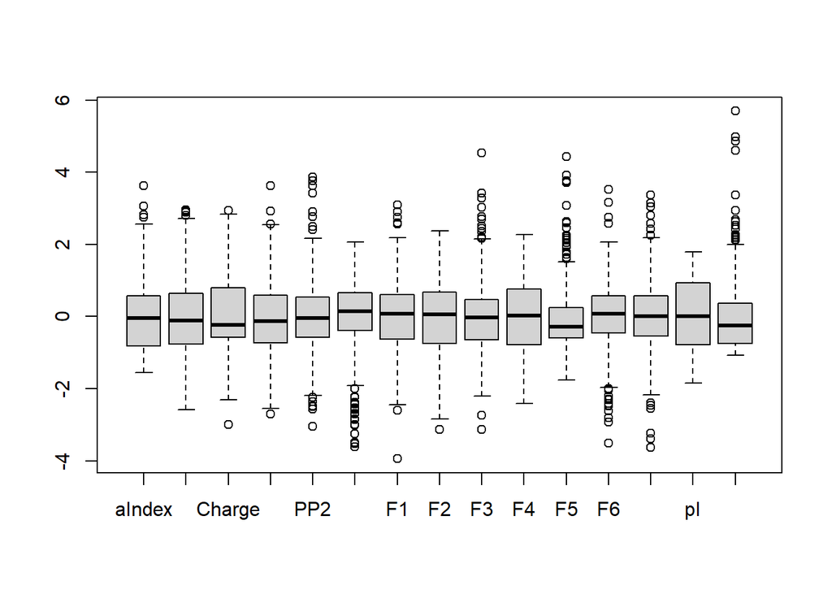

```r
boxplot(pepscale5)
```

## Calculo PCAs y obtención de archivo Excel de rotación

```r
PCApep5 = prcomp(pepscale5)
summary(PCApep5)
```

```
## Importance of components:
##                           PC1    PC2    PC3    PC4     PC5     PC6    PC7
## Standard deviation     2.1920 1.7510 1.4607 1.3029 1.06468 0.84614 0.6434
## Proportion of Variance 0.3203 0.2044 0.1422 0.1132 0.07557 0.04773 0.0276
## Cumulative Proportion  0.3203 0.5247 0.6670 0.7801 0.85568 0.90341 0.9310
##                            PC8     PC9    PC10    PC11    PC12    PC13    PC14
## Standard deviation     0.60316 0.47780 0.38601 0.34320 0.29417 0.22767 0.15638
## Proportion of Variance 0.02425 0.01522 0.00993 0.00785 0.00577 0.00346 0.00163
## Cumulative Proportion  0.95526 0.97048 0.98041 0.98827 0.99404 0.99749 0.99912
##                           PC15
## Standard deviation     0.11481
## Proportion of Variance 0.00088
## Cumulative Proportion  1.00000
```

```r
##write.csv2(PCApep5, "PCApep5.csv")##
```

## Para escoger el numero de PCAs

```r
stdev5= PCApep5$sdev
pr_var5 = stdev5^2
pr_var5[1:15]
```

```
##  [1] 4.80489083 3.06582721 2.13351857 1.69743741 1.13354241 0.71594699
##  [7] 0.41394083 0.36380646 0.22829107 0.14900092 0.11778835 0.08653851
## [13] 0.05183481 0.02445451 0.01318111
```

```r
prop_varex5 =pr_var5/sum(pr_var5)
prop_varex5[1:15]
```

```
##  [1] 0.3203260550 0.2043884809 0.1422345715 0.1131624937 0.0755694942
##  [6] 0.0477297996 0.0275960556 0.0242537639 0.0152194045 0.0099333949
## [11] 0.0078525569 0.0057692342 0.0034556542 0.0016303003 0.0008787405
```

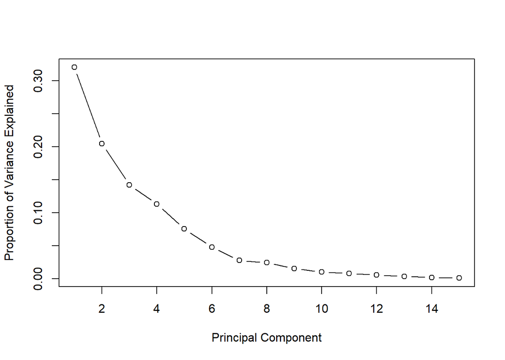

```r
plot(prop_varex5, xlab = "Principal Component",ylab = "Proportion of Variance Explained",type = "b")
```

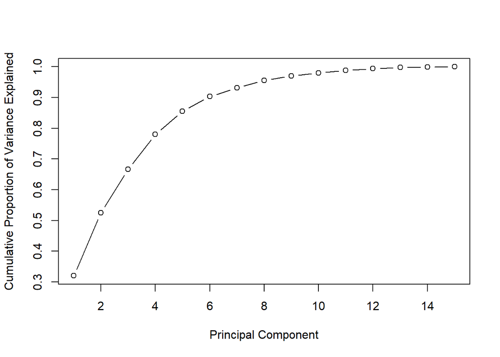

```r
plot(cumsum(prop_varex5), xlab = "Principal Component",ylab = "Cumulative Proportion of Variance Explained",type = "b")
```

## Determinar numero optimo de clusters por medio del metodo de “avarage silhouette”

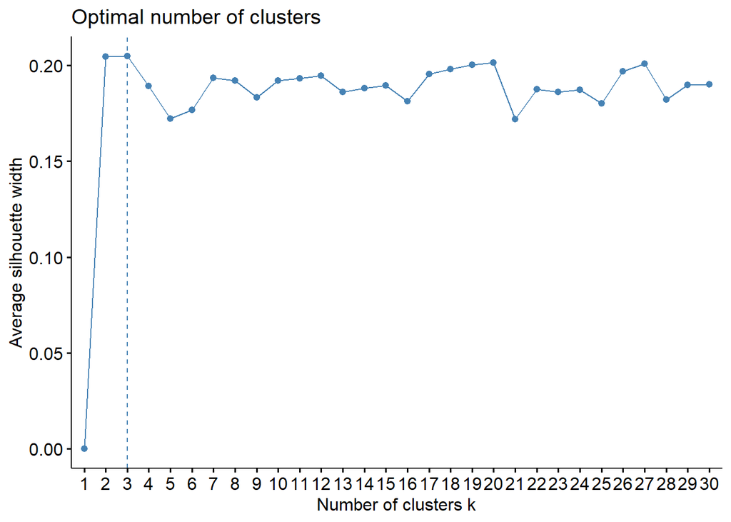

```r
fviz_nbclust(PCApep5$x[ ,1:15],kmeans,method = "silhouette", k.max = 30, iter.max=25)
```

## Graficar heatmap

## Heatmap de 5 clusters

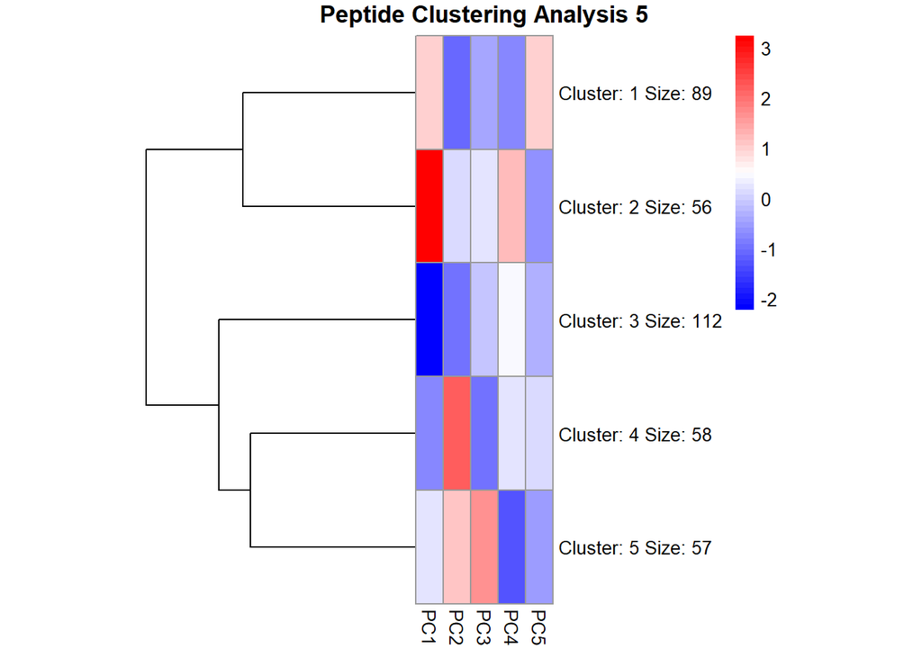

```r
cluster5pep= pheatmap(PCApep5$x[,1:5], kmeans_k = 5,cluster_cols = FALSE, treeheight_row = 150, cellwidth = 15, color = colorRampPalette(c("blue", "white", "red"))(50),main = "Peptide Clustering Analysis 5" )
```

```r
write.csv2 (cluster5pep$kmeans$cluster, file="clustermemberS5pep.csv")
```

# 6 clusters

## Leer archivo fuente, este es un excel, cambie un poco el codigo para usar lo que se

```r
Lista_calculo6 <- read_excel("C:/Users/javeb/Documents/R/TESIS/SESGADOS/CLUSTER_6.xlsx")
View(Lista_calculo6)
```

## Ahora a obtener los descriptores, verlo y guardarlos en un archivo Excel

```r
peptideDescriptors6 <- data.frame(
  Name = unlist(Lista_calculo6$Name),
  sequence = unlist(Lista_calculo6$Sequence),
  aIndex = aIndex(Lista_calculo6$Sequence),
  boman = boman(Lista_calculo6$Sequence),
  charge = charge(Lista_calculo6$Sequence, pH = 7, pKscale = "Sillero"),
  crucianiProperties = do.call(rbind.data.frame, crucianiProperties(Lista_calculo6$Sequence)),
  fasgaiVectors = do.call(rbind.data.frame, fasgaiVectors(Lista_calculo6$Sequence)),
  hydrophobicity = hydrophobicity(Lista_calculo6$Sequence, scale="Kidera"),
  pI = pI(Lista_calculo6$Sequence, pKscale="EMBOSS"),mw = mw(Lista_calculo6$Sequence))
colnames(peptideDescriptors6) <- c('Name','sequence', "aIndex", "Boman", "Charge", paste0('PP', 1:3), paste0('F', 1:6), "Hidrophobicity","pI", "MW")
view(peptideDescriptors6)
Tabla = subset(peptideDescriptors6, select = -c(sequence))
knitr::kable(Tabla, caption = "**Tabla 1.** Descriptores")
```

**Tabla 1.** Descriptores

| Name | aIndex | Boman | Charge | PP1 | PP2 | PP3 | F1 | F2 | F3 | F4 | F5 | F6 | Hidrophobicity | pI | MW |
| --- | --- | --- | --- | --- | --- | --- | --- | --- | --- | --- | --- | --- | --- | --- | --- |
| >Antiox_1 | 103.33333 | 0.5627778 | -1.0538969 | -0.3300000 | -0.4538889 | 0.0927778 | -0.1120556 | 0.0165000 | -0.3827222 | 0.8094444 | 0.1480000 | -0.2091667 | -0.0222222 | 4.258141 | 1805.0177 |
| >Antiox_2 | 37.69231 | 1.9584615 | 1.3324165 | -0.0876923 | -0.3384615 | 0.2761538 | -0.1028462 | -0.4549231 | -0.4346154 | -0.0149231 | 0.0067692 | -0.1303077 | -0.0753846 | 8.564801 | 1421.5558 |
| >Antiox_3 | 14.28571 | 3.9257143 | -4.0497356 | 0.3371429 | -0.4642857 | -0.5614286 | -0.7451429 | 0.2350000 | -0.2124286 | 0.1777143 | 0.5840000 | -1.0128571 | 0.3914286 | 3.331708 | 851.8218 |
| >Antiox_6 | 97.50000 | 0.7975000 | 1.9364036 | -0.1325000 | -0.0993750 | 0.0862500 | -0.0538125 | -0.2690625 | 0.3640000 | 0.2704375 | 0.2588125 | 0.2653125 | -0.0962500 | 9.634027 | 1961.2909 |
| >Antiox_8 | 20.00000 | 2.6960000 | 0.3423275 | 0.2380000 | -0.4880000 | 0.3980000 | -0.1720000 | 0.0892000 | -0.5492000 | -0.1008000 | 0.0434000 | 0.0494000 | 0.2680000 | 7.714355 | 551.5595 |
| >Antiox_9 | 55.71429 | 2.1071429 | 0.9397985 | -0.2414286 | -0.1771429 | 0.0628571 | -0.5312857 | -0.4012857 | 0.0167143 | 0.1278571 | 0.9430000 | 0.2348571 | 0.0342857 | 9.348818 | 829.9542 |
| >Antiox_11 | 84.28571 | -0.1257143 | -0.0690935 | -0.4271429 | -0.4971429 | 0.0985714 | 0.1184286 | 0.0410000 | -0.6315714 | 0.3710000 | 0.5292857 | -0.2300000 | -0.2742857 | 5.922539 | 688.7966 |
| >Antiox_13 | 70.00000 | 3.8142857 | -2.0522868 | 0.3428571 | -0.4142857 | -0.3271429 | -0.6937143 | 0.7477143 | -0.1958571 | 0.4885714 | 0.1398571 | -0.5067143 | 0.6542857 | 3.927560 | 831.8778 |
| >Antiox_14 | 12.50000 | 3.5250000 | -3.0540422 | 0.1912500 | -0.5487500 | -0.3550000 | -0.5213750 | 0.0700000 | -0.4348750 | 0.0118750 | 0.4875000 | -0.7272500 | 0.3462500 | 3.380031 | 905.9318 |
| >Antiox_15 | 65.00000 | 0.3666667 | -1.0601915 | -0.1733333 | -0.3366667 | -0.1100000 | 0.0250000 | -0.9116667 | 0.0521667 | 0.5381667 | -0.6038333 | -0.6028333 | -0.2883333 | 3.749971 | 686.7190 |
| >Antiox_16 | 0.00000 | 4.1466667 | -0.8574335 | 0.2633333 | -0.6666667 | -0.0466667 | -0.5910000 | -0.7340000 | -0.7546667 | -0.1176667 | -0.4576667 | -0.9130000 | 0.3100000 | 5.292276 | 327.2968 |
| >Antiox_18 | 0.00000 | 5.6620000 | -0.8546791 | 0.7220000 | -0.4160000 | -0.0500000 | -0.8672000 | 0.3054000 | -0.2588000 | -0.1390000 | 0.0228000 | -0.2324000 | 0.9180000 | 5.454283 | 628.6396 |
| >Antiox_19 | 127.00000 | -0.6010000 | -0.8574335 | -0.5440000 | -0.5070000 | 0.0360000 | 0.1217000 | -0.4473000 | -0.5040000 | 0.9076000 | 0.1915000 | -0.7162000 | -0.3710000 | 5.292276 | 949.0743 |
| >Antiox_20 | 58.00000 | 1.9420000 | -1.0581935 | -0.0140000 | -0.7560000 | 0.0580000 | -0.6724000 | -0.6830000 | -0.7800000 | 0.6006000 | -0.2902000 | -0.2722000 | 0.2600000 | 3.749973 | 477.4716 |
| >Antiox_21 | 0.00000 | 3.0000000 | -1.0601915 | 0.5400000 | -0.0166667 | -0.4666667 | -0.2133333 | -0.7200000 | 0.9740000 | -0.3776667 | -0.6430000 | -0.3946667 | -0.1033333 | 3.749971 | 459.4558 |
| >Antiox_23 | 110.00000 | 2.9962500 | -3.0518889 | 0.2200000 | -0.4762500 | -0.3887500 | -0.4258750 | 0.4413750 | -0.2206250 | 0.5815000 | 0.0807500 | -0.8075000 | 0.2875000 | 3.424715 | 916.9400 |
| >Antiox_24 | 292.50000 | -1.9875000 | -1.0560402 | -0.4500000 | -0.1325000 | -0.4125000 | 0.6437500 | 1.0450000 | 0.4635000 | 1.1887500 | 0.3250000 | -0.2895000 | -0.4500000 | 3.849974 | 486.6089 |
| >Antiox_25 | 24.37500 | 2.9368750 | -1.8610398 | 0.0368750 | -0.4062500 | -0.0450000 | -0.4478125 | -0.2468125 | -0.3935000 | -0.0433750 | 0.6785000 | -0.2118125 | 0.1493750 | 4.421435 | 1799.9325 |
| >Antiox_26 | 55.71429 | 3.5728571 | 0.1437108 | 0.2028571 | -0.1128571 | 0.0614286 | -0.3172857 | -0.0554286 | 0.1348571 | 0.0510000 | 0.5651429 | 0.0808571 | 0.1900000 | 7.543349 | 900.9896 |
| >Antiox_28 | 0.00000 | -0.6480000 | -0.0591925 | -0.5220000 | -0.0260000 | -0.2460000 | 0.5054000 | -0.4558000 | 0.3848000 | 0.1508000 | -0.3236000 | -0.3592000 | -0.7280000 | 6.099982 | 630.7007 |
| >Antiox_32 | 97.50000 | -0.2725000 | -1.0560402 | -0.4050000 | -0.1075000 | -0.4700000 | 0.1727500 | 0.1927500 | 0.2785000 | 0.4907500 | 1.2047500 | -0.6417500 | -0.5275000 | 3.849974 | 504.5834 |
| >Antiox_34 | 72.50000 | 0.1612500 | 0.9404096 | -0.3812500 | -0.3400000 | 0.1425000 | -0.5760000 | -0.4768750 | -0.2008750 | 0.4083750 | 0.8936250 | 0.1082500 | -0.1487500 | 9.700016 | 860.0209 |
| >Antiox_35 | 78.00000 | -0.8440000 | 0.9404096 | -0.6180000 | -0.3220000 | 0.2160000 | -0.2940000 | 0.0024000 | -0.2030000 | 0.7898000 | -0.2876000 | 0.0868000 | -0.1120000 | 9.700016 | 520.6292 |
| >Antiox_36 | 66.66667 | -1.5200000 | -0.0591925 | -0.9333333 | -0.8400000 | 0.3700000 | 0.0696667 | -0.1923333 | -1.2246667 | 1.3343333 | -0.3296667 | -0.7820000 | -0.2333333 | 6.099982 | 217.2247 |
| >Antiox_37 | 70.00000 | 1.4942857 | 0.9407975 | -0.2728571 | -0.1142857 | 0.0900000 | -0.0671429 | -0.2320000 | 0.0021429 | 0.3212857 | 0.3470000 | -0.0345714 | -0.1257143 | 10.549999 | 826.9534 |
| >Antiox_38 | 40.83333 | 1.0450000 | 0.9407975 | -0.4858333 | -0.5200000 | 0.2333333 | -0.2312500 | -1.0610000 | -0.7300000 | 0.6150833 | 0.6420833 | -0.4115833 | -0.0550000 | 10.549999 | 1107.2344 |
| >Antiox_40 | 0.00000 | 3.4300000 | -0.0659512 | 0.1300000 | -0.2000000 | 0.1300000 | -0.2395000 | -0.2256667 | -0.3216667 | -0.2906667 | -0.3861667 | 0.0555000 | 0.1133333 | 6.232445 | 736.8003 |
| >Antiox_41 | 65.00000 | -0.4950000 | -1.0560402 | -0.5633333 | -0.4050000 | -0.1500000 | 0.0468333 | -0.6111667 | -0.3663333 | 0.7368333 | 0.4315000 | -0.8098333 | -0.4050000 | 3.849974 | 618.6872 |
| >Antiox_43 | 0.00000 | 3.2600000 | 0.9407975 | -0.4425000 | -0.4425000 | 0.4750000 | -0.5115000 | -1.5245000 | -0.8400000 | 0.5005000 | 0.3912500 | -0.1680000 | 0.2000000 | 10.549999 | 385.4232 |
| >Antiox_44 | 83.57143 | 0.4300000 | -0.0560502 | -0.3557143 | -0.1550000 | -0.0814286 | 0.0213571 | -0.1697857 | 0.1147143 | 0.3172143 | 0.4226429 | -0.1179286 | -0.2964286 | 6.410139 | 1646.9090 |

[output cut: 366 more lines]

```r
write.csv2(peptideDescriptors6, "Descriptores6.csv")
```

## Quito primera y segunda fila y exploratorio de datos

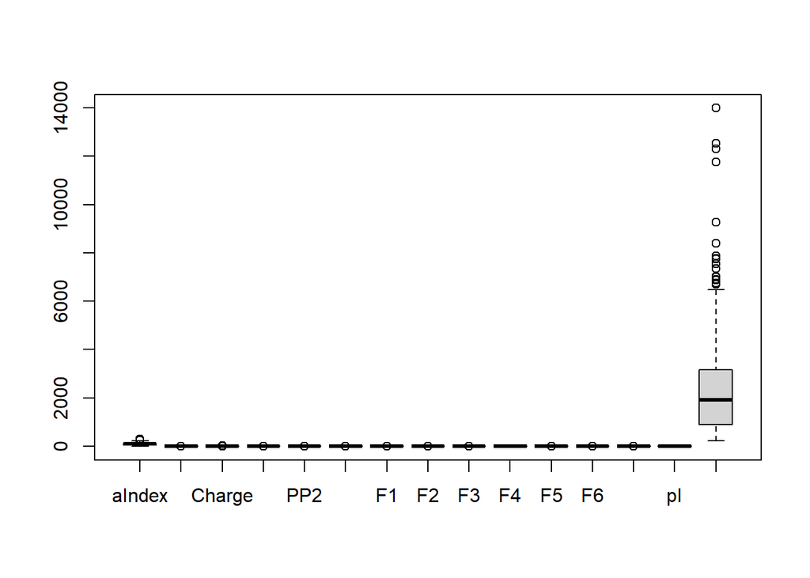

```r
datapep6= subset(peptideDescriptors6, select = -c(Name, sequence))
view(datapep6)
boxplot(datapep6)
```

```r
summary(datapep6)
```

```
##      aIndex           Boman             Charge             PP1
##  Min.   :  0.00   Min.   :-3.2050   Min.   :-7.0470   Min.   :-0.93333
##  1st Qu.: 43.84   1st Qu.:-0.1600   1st Qu.:-0.0593   1st Qu.:-0.40947
##  Median : 85.66   Median : 0.8677   Median : 0.9408   Median :-0.23339
##  Mean   : 87.80   Mean   : 1.0525   Mean   : 1.8568   Mean   :-0.21376
##  3rd Qu.:120.00   3rd Qu.: 2.1442   3rd Qu.: 3.9392   3rd Qu.:-0.04469
##  Max.   :292.50   Max.   : 5.8771   Max.   :12.9380   Max.   : 0.72200
##       PP2               PP3                 F1                F2
##  Min.   :-0.8400   Min.   :-0.58083   Min.   :-1.3503   Min.   :-1.52450
##  1st Qu.:-0.3946   1st Qu.: 0.02322   1st Qu.:-0.3361   1st Qu.:-0.34456
##  Median :-0.2938   Median : 0.12548   Median :-0.1195   Median : 0.00589
##  Mean   :-0.2786   Mean   : 0.10130   Mean   :-0.1455   Mean   :-0.01997
##  3rd Qu.:-0.1811   3rd Qu.: 0.21942   3rd Qu.: 0.0366   3rd Qu.: 0.29314
##  Max.   : 0.3954   Max.   : 0.49286   Max.   : 0.8100   Max.   : 1.09789
##        F3                 F4                 F5                 F6
##  Min.   :-1.22467   Min.   :-0.62400   Min.   :-0.67725   Min.   :-1.20275
##  1st Qu.:-0.36491   1st Qu.: 0.09064   1st Qu.:-0.11984   1st Qu.:-0.20334
##  Median :-0.15437   Median : 0.40849   Median : 0.03128   Median :-0.01716
##  Mean   :-0.13042   Mean   : 0.40856   Mean   : 0.15822   Mean   :-0.02619
##  3rd Qu.: 0.04339   3rd Qu.: 0.72341   3rd Qu.: 0.27728   3rd Qu.: 0.16787
##  Max.   : 1.40100   Max.   : 1.39913   Max.   : 2.29467   Max.   : 1.14658
##  Hidrophobicity             pI               MW
##  Min.   :-1.0950000   Min.   : 3.167   Min.   :  217.2
##  1st Qu.:-0.1545323   1st Qu.: 6.100   1st Qu.:  905.2
##  Median : 0.0040556   Median : 8.980   Median : 1917.4
##  Mean   : 0.0003485   Mean   : 8.506   Mean   : 2406.0
##  3rd Qu.: 0.1829155   3rd Qu.:11.102   3rd Qu.: 3163.4
##  Max.   : 0.9820000   Max.   :13.278   Max.   :13992.9
```

## Normalizar y ver cambios

```r
pepscale6 = scale(datapep6)
summary(pepscale6)
```

```
##      aIndex             Boman             Charge             PP1
##  Min.   :-1.57219   Min.   :-2.5857   Min.   :-2.9360   Min.   :-2.76280
##  1st Qu.:-0.78719   1st Qu.:-0.7364   1st Qu.:-0.6318   1st Qu.:-0.75141
##  Median :-0.03832   Median :-0.1122   Median :-0.3021   Median :-0.07538
##  Mean   : 0.00000   Mean   : 0.0000   Mean   : 0.0000   Mean   : 0.00000
##  3rd Qu.: 0.57669   3rd Qu.: 0.6630   3rd Qu.: 0.6867   3rd Qu.: 0.64916
##  Max.   : 3.66569   Max.   : 2.9302   Max.   : 3.6540   Max.   : 3.59285
##       PP2                PP3                F1                 F2
##  Min.   :-2.97083   Min.   :-3.6231   Min.   :-4.00230   Min.   :-3.20945
##  1st Qu.:-0.61420   1st Qu.:-0.4147   1st Qu.:-0.63314   1st Qu.:-0.69241
##  Median :-0.08081   Median : 0.1284   Median : 0.08653   Median : 0.05516
##  Mean   : 0.00000   Mean   : 0.0000   Mean   : 0.00000   Mean   : 0.00000
##  3rd Qu.: 0.51577   3rd Qu.: 0.6274   3rd Qu.: 0.60501   3rd Qu.: 0.66790
##  Max.   : 3.56620   Max.   : 2.0797   Max.   : 3.17420   Max.   : 2.38459
##        F3                 F4                   F5                F6
##  Min.   :-3.13034   Min.   :-2.4310807   Min.   :-1.7716   Min.   :-3.30108
##  1st Qu.:-0.67080   1st Qu.:-0.7485010   1st Qu.:-0.5896   1st Qu.:-0.49703
##  Median :-0.06852   Median :-0.0001479   Median :-0.2692   Median : 0.02534
##  Mean   : 0.00000   Mean   : 0.0000000   Mean   : 0.0000   Mean   : 0.00000
##  3rd Qu.: 0.49722   3rd Qu.: 0.7413069   3rd Qu.: 0.2525   3rd Qu.: 0.54446
##  Max.   : 4.38097   Max.   : 2.3322387   Max.   : 4.5304   Max.   : 3.29045
##  Hidrophobicity          pI                MW
##  Min.   :-3.6630   Min.   :-1.8753   Min.   :-1.1026
##  1st Qu.:-0.5179   1st Qu.:-0.8451   1st Qu.:-0.7561
##  Median : 0.0124   Median : 0.1663   Median :-0.2462
##  Mean   : 0.0000   Mean   : 0.0000   Mean   : 0.0000
##  3rd Qu.: 0.6105   3rd Qu.: 0.9117   3rd Qu.: 0.3815
##  Max.   : 3.2828   Max.   : 1.6760   Max.   : 5.8369
```

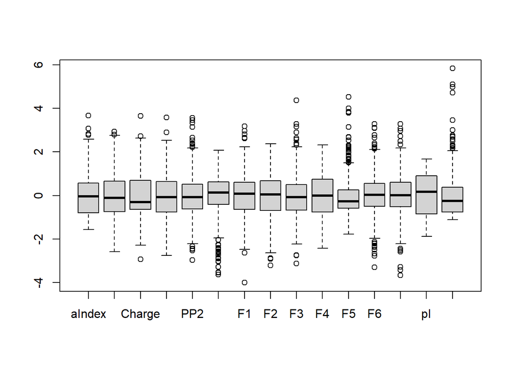

```r
boxplot(pepscale6)
```

## Calculo PCAs y obtención de archivo Excel de rotación

```r
PCApep6 = prcomp(pepscale6)
summary(PCApep6)
```

```
## Importance of components:
##                           PC1    PC2    PC3    PC4     PC5     PC6     PC7
## Standard deviation     2.1415 1.8396 1.4440 1.2825 1.07507 0.84978 0.61733
## Proportion of Variance 0.3057 0.2256 0.1390 0.1096 0.07705 0.04814 0.02541
## Cumulative Proportion  0.3057 0.5313 0.6704 0.7800 0.85706 0.90520 0.93060
##                            PC8     PC9   PC10    PC11    PC12   PC13   PC14
## Standard deviation     0.60265 0.48346 0.3854 0.34152 0.30549 0.2224 0.1547
## Proportion of Variance 0.02421 0.01558 0.0099 0.00778 0.00622 0.0033 0.0016
## Cumulative Proportion  0.95482 0.97040 0.9803 0.98807 0.99430 0.9976 0.9992
##                           PC15
## Standard deviation     0.11027
## Proportion of Variance 0.00081
## Cumulative Proportion  1.00000
```

```r
##write.csv2(PCApep6, "PCApep6.csv")##
```

## Para escoger el numero de PCAs

```r
stdev6= PCApep6$sdev
pr_var6 = stdev6^2
pr_var6[1:15]
```

```
##  [1] 4.58591336 3.38430300 2.08509192 1.64475332 1.15577428 0.72212223
##  [7] 0.38109899 0.36319296 0.23373816 0.14849743 0.11663856 0.09332613
## [13] 0.04946179 0.02392872 0.01215915
```

```r
prop_varex6 =pr_var6/sum(pr_var6)
prop_varex6[1:15]
```

```
##  [1] 0.305727557 0.225620200 0.139006128 0.109650221 0.077051619 0.048141482
##  [7] 0.025406600 0.024212864 0.015582544 0.009899828 0.007775904 0.006221742
## [13] 0.003297453 0.001595248 0.000810610
```

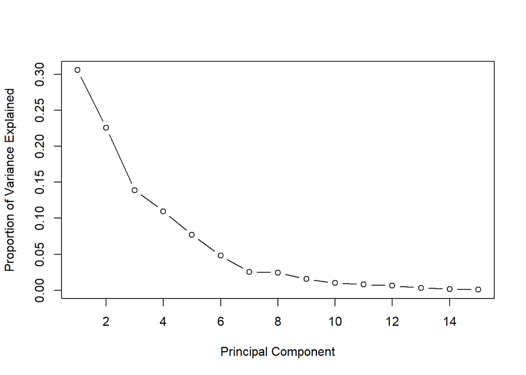

```r
plot(prop_varex6, xlab = "Principal Component",ylab = "Proportion of Variance Explained",type = "b")
```

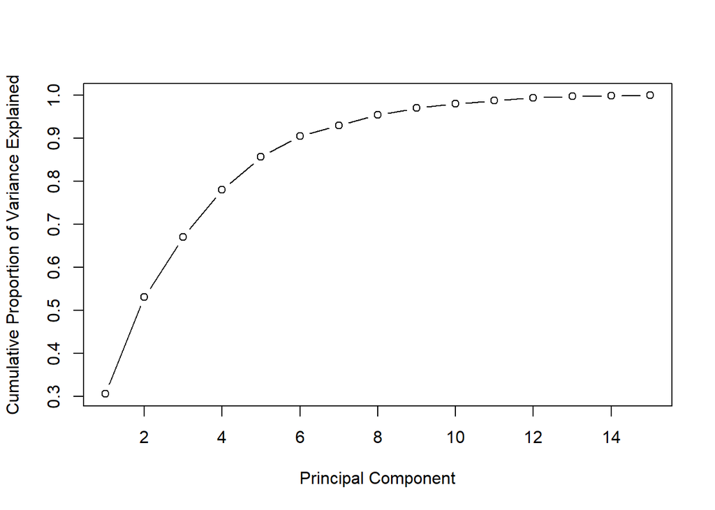

```r
plot(cumsum(prop_varex6), xlab = "Principal Component",ylab = "Cumulative Proportion of Variance Explained",type = "b")
```

## Determinar numero optimo de clusters por medio del metodo de “avarage silhouette”

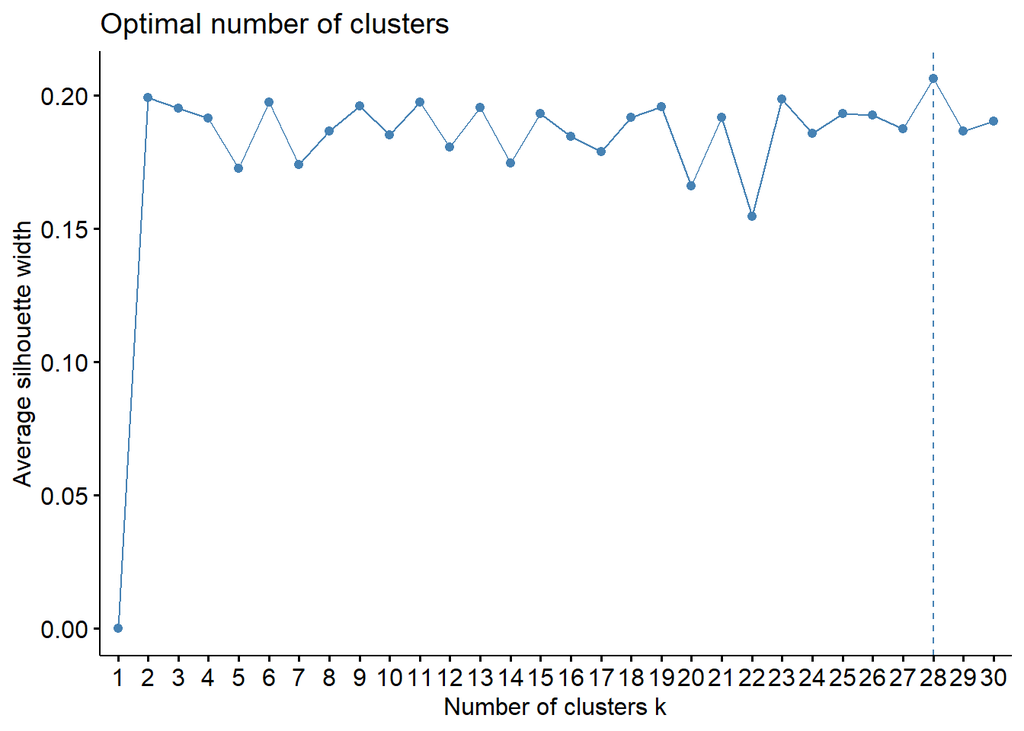

```r
fviz_nbclust(PCApep6$x[ ,1:15],kmeans,method = "silhouette", k.max = 30, iter.max=25)
```

## Graficar heatmap

## Heatmap de 6 clusters

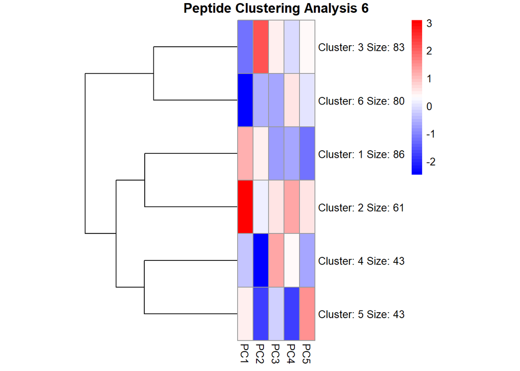

```r
cluster6pep= pheatmap(PCApep6$x[,1:5], kmeans_k = 6,cluster_cols = FALSE, treeheight_row = 150, cellwidth = 15, color = colorRampPalette(c("blue", "white", "red"))(50),main = "Peptide Clustering Analysis 6" )
```

```r
write.csv2 (cluster6pep$kmeans$cluster, file="clustermemberS6pep.csv")
```

# 7 clusters

## Leer archivo fuente, este es un excel, cambie un poco el codigo para usar lo que se

```r
Lista_calculo7 <- read_excel("C:/Users/javeb/Documents/R/TESIS/SESGADOS/CLUSTER_7.xlsx")
View(Lista_calculo7)
```

## Ahora a obtener los descriptores, verlo y guardarlos en un archivo Excel

```r
peptideDescriptors7 <- data.frame(
  Name = unlist(Lista_calculo7$Name),
  sequence = unlist(Lista_calculo7$Sequence),
  aIndex = aIndex(Lista_calculo7$Sequence),
  boman = boman(Lista_calculo7$Sequence),
  charge = charge(Lista_calculo7$Sequence, pH = 7, pKscale = "Sillero"),
  crucianiProperties = do.call(rbind.data.frame, crucianiProperties(Lista_calculo7$Sequence)),
  fasgaiVectors = do.call(rbind.data.frame, fasgaiVectors(Lista_calculo7$Sequence)),
  hydrophobicity = hydrophobicity(Lista_calculo7$Sequence, scale="Kidera"),
  pI = pI(Lista_calculo7$Sequence, pKscale="EMBOSS"),mw = mw(Lista_calculo7$Sequence))
colnames(peptideDescriptors7) <- c('Name','sequence', "aIndex", "Boman", "Charge", paste0('PP', 1:3), paste0('F', 1:6), "Hidrophobicity","pI", "MW")
view(peptideDescriptors7)
Tabla = subset(peptideDescriptors7, select = -c(sequence))
knitr::kable(Tabla, caption = "**Tabla 1.** Descriptores")
```

**Tabla 1.** Descriptores

| Name | aIndex | Boman | Charge | PP1 | PP2 | PP3 | F1 | F2 | F3 | F4 | F5 | F6 | Hidrophobicity | pI | MW |
| --- | --- | --- | --- | --- | --- | --- | --- | --- | --- | --- | --- | --- | --- | --- | --- |
| >Antiox_1 | 103.33333 | 0.5627778 | -1.0538969 | -0.3300000 | -0.4538889 | 0.0927778 | -0.1120556 | 0.0165000 | -0.3827222 | 0.8094444 | 0.1480000 | -0.2091667 | -0.0222222 | 4.258141 | 1805.0177 |
| >Antiox_2 | 37.69231 | 1.9584615 | 1.3324165 | -0.0876923 | -0.3384615 | 0.2761538 | -0.1028462 | -0.4549231 | -0.4346154 | -0.0149231 | 0.0067692 | -0.1303077 | -0.0753846 | 8.564801 | 1421.5558 |
| >Antiox_3 | 14.28571 | 3.9257143 | -4.0497356 | 0.3371429 | -0.4642857 | -0.5614286 | -0.7451429 | 0.2350000 | -0.2124286 | 0.1777143 | 0.5840000 | -1.0128571 | 0.3914286 | 3.331708 | 851.8218 |
| >Antiox_6 | 97.50000 | 0.7975000 | 1.9364036 | -0.1325000 | -0.0993750 | 0.0862500 | -0.0538125 | -0.2690625 | 0.3640000 | 0.2704375 | 0.2588125 | 0.2653125 | -0.0962500 | 9.634027 | 1961.2909 |
| >Antiox_8 | 20.00000 | 2.6960000 | 0.3423275 | 0.2380000 | -0.4880000 | 0.3980000 | -0.1720000 | 0.0892000 | -0.5492000 | -0.1008000 | 0.0434000 | 0.0494000 | 0.2680000 | 7.714355 | 551.5595 |
| >Antiox_9 | 55.71429 | 2.1071429 | 0.9397985 | -0.2414286 | -0.1771429 | 0.0628571 | -0.5312857 | -0.4012857 | 0.0167143 | 0.1278571 | 0.9430000 | 0.2348571 | 0.0342857 | 9.348818 | 829.9542 |
| >Antiox_11 | 84.28571 | -0.1257143 | -0.0690935 | -0.4271429 | -0.4971429 | 0.0985714 | 0.1184286 | 0.0410000 | -0.6315714 | 0.3710000 | 0.5292857 | -0.2300000 | -0.2742857 | 5.922539 | 688.7966 |
| >Antiox_13 | 70.00000 | 3.8142857 | -2.0522868 | 0.3428571 | -0.4142857 | -0.3271429 | -0.6937143 | 0.7477143 | -0.1958571 | 0.4885714 | 0.1398571 | -0.5067143 | 0.6542857 | 3.927560 | 831.8778 |
| >Antiox_14 | 12.50000 | 3.5250000 | -3.0540422 | 0.1912500 | -0.5487500 | -0.3550000 | -0.5213750 | 0.0700000 | -0.4348750 | 0.0118750 | 0.4875000 | -0.7272500 | 0.3462500 | 3.380031 | 905.9318 |
| >Antiox_15 | 65.00000 | 0.3666667 | -1.0601915 | -0.1733333 | -0.3366667 | -0.1100000 | 0.0250000 | -0.9116667 | 0.0521667 | 0.5381667 | -0.6038333 | -0.6028333 | -0.2883333 | 3.749971 | 686.7190 |
| >Antiox_16 | 0.00000 | 4.1466667 | -0.8574335 | 0.2633333 | -0.6666667 | -0.0466667 | -0.5910000 | -0.7340000 | -0.7546667 | -0.1176667 | -0.4576667 | -0.9130000 | 0.3100000 | 5.292276 | 327.2968 |
| >Antiox_18 | 0.00000 | 5.6620000 | -0.8546791 | 0.7220000 | -0.4160000 | -0.0500000 | -0.8672000 | 0.3054000 | -0.2588000 | -0.1390000 | 0.0228000 | -0.2324000 | 0.9180000 | 5.454283 | 628.6396 |
| >Antiox_19 | 127.00000 | -0.6010000 | -0.8574335 | -0.5440000 | -0.5070000 | 0.0360000 | 0.1217000 | -0.4473000 | -0.5040000 | 0.9076000 | 0.1915000 | -0.7162000 | -0.3710000 | 5.292276 | 949.0743 |
| >Antiox_20 | 58.00000 | 1.9420000 | -1.0581935 | -0.0140000 | -0.7560000 | 0.0580000 | -0.6724000 | -0.6830000 | -0.7800000 | 0.6006000 | -0.2902000 | -0.2722000 | 0.2600000 | 3.749973 | 477.4716 |
| >Antiox_21 | 0.00000 | 3.0000000 | -1.0601915 | 0.5400000 | -0.0166667 | -0.4666667 | -0.2133333 | -0.7200000 | 0.9740000 | -0.3776667 | -0.6430000 | -0.3946667 | -0.1033333 | 3.749971 | 459.4558 |
| >Antiox_23 | 110.00000 | 2.9962500 | -3.0518889 | 0.2200000 | -0.4762500 | -0.3887500 | -0.4258750 | 0.4413750 | -0.2206250 | 0.5815000 | 0.0807500 | -0.8075000 | 0.2875000 | 3.424715 | 916.9400 |
| >Antiox_24 | 292.50000 | -1.9875000 | -1.0560402 | -0.4500000 | -0.1325000 | -0.4125000 | 0.6437500 | 1.0450000 | 0.4635000 | 1.1887500 | 0.3250000 | -0.2895000 | -0.4500000 | 3.849974 | 486.6089 |
| >Antiox_25 | 24.37500 | 2.9368750 | -1.8610398 | 0.0368750 | -0.4062500 | -0.0450000 | -0.4478125 | -0.2468125 | -0.3935000 | -0.0433750 | 0.6785000 | -0.2118125 | 0.1493750 | 4.421435 | 1799.9325 |
| >Antiox_26 | 55.71429 | 3.5728571 | 0.1437108 | 0.2028571 | -0.1128571 | 0.0614286 | -0.3172857 | -0.0554286 | 0.1348571 | 0.0510000 | 0.5651429 | 0.0808571 | 0.1900000 | 7.543349 | 900.9896 |
| >Antiox_28 | 0.00000 | -0.6480000 | -0.0591925 | -0.5220000 | -0.0260000 | -0.2460000 | 0.5054000 | -0.4558000 | 0.3848000 | 0.1508000 | -0.3236000 | -0.3592000 | -0.7280000 | 6.099982 | 630.7007 |
| >Antiox_32 | 97.50000 | -0.2725000 | -1.0560402 | -0.4050000 | -0.1075000 | -0.4700000 | 0.1727500 | 0.1927500 | 0.2785000 | 0.4907500 | 1.2047500 | -0.6417500 | -0.5275000 | 3.849974 | 504.5834 |
| >Antiox_34 | 72.50000 | 0.1612500 | 0.9404096 | -0.3812500 | -0.3400000 | 0.1425000 | -0.5760000 | -0.4768750 | -0.2008750 | 0.4083750 | 0.8936250 | 0.1082500 | -0.1487500 | 9.700016 | 860.0209 |
| >Antiox_35 | 78.00000 | -0.8440000 | 0.9404096 | -0.6180000 | -0.3220000 | 0.2160000 | -0.2940000 | 0.0024000 | -0.2030000 | 0.7898000 | -0.2876000 | 0.0868000 | -0.1120000 | 9.700016 | 520.6292 |
| >Antiox_36 | 66.66667 | -1.5200000 | -0.0591925 | -0.9333333 | -0.8400000 | 0.3700000 | 0.0696667 | -0.1923333 | -1.2246667 | 1.3343333 | -0.3296667 | -0.7820000 | -0.2333333 | 6.099982 | 217.2247 |
| >Antiox_37 | 70.00000 | 1.4942857 | 0.9407975 | -0.2728571 | -0.1142857 | 0.0900000 | -0.0671429 | -0.2320000 | 0.0021429 | 0.3212857 | 0.3470000 | -0.0345714 | -0.1257143 | 10.549999 | 826.9534 |
| >Antiox_38 | 40.83333 | 1.0450000 | 0.9407975 | -0.4858333 | -0.5200000 | 0.2333333 | -0.2312500 | -1.0610000 | -0.7300000 | 0.6150833 | 0.6420833 | -0.4115833 | -0.0550000 | 10.549999 | 1107.2344 |
| >Antiox_40 | 0.00000 | 3.4300000 | -0.0659512 | 0.1300000 | -0.2000000 | 0.1300000 | -0.2395000 | -0.2256667 | -0.3216667 | -0.2906667 | -0.3861667 | 0.0555000 | 0.1133333 | 6.232445 | 736.8003 |
| >Antiox_41 | 65.00000 | -0.4950000 | -1.0560402 | -0.5633333 | -0.4050000 | -0.1500000 | 0.0468333 | -0.6111667 | -0.3663333 | 0.7368333 | 0.4315000 | -0.8098333 | -0.4050000 | 3.849974 | 618.6872 |
| >Antiox_43 | 0.00000 | 3.2600000 | 0.9407975 | -0.4425000 | -0.4425000 | 0.4750000 | -0.5115000 | -1.5245000 | -0.8400000 | 0.5005000 | 0.3912500 | -0.1680000 | 0.2000000 | 10.549999 | 385.4232 |
| >Antiox_44 | 83.57143 | 0.4300000 | -0.0560502 | -0.3557143 | -0.1550000 | -0.0814286 | 0.0213571 | -0.1697857 | 0.1147143 | 0.3172143 | 0.4226429 | -0.1179286 | -0.2964286 | 6.410139 | 1646.9090 |

[output cut: 383 more lines]

```r
write.csv2(peptideDescriptors7, "Descriptores7.csv")
```

## Quito primera y segunda fila y exploratorio de datos

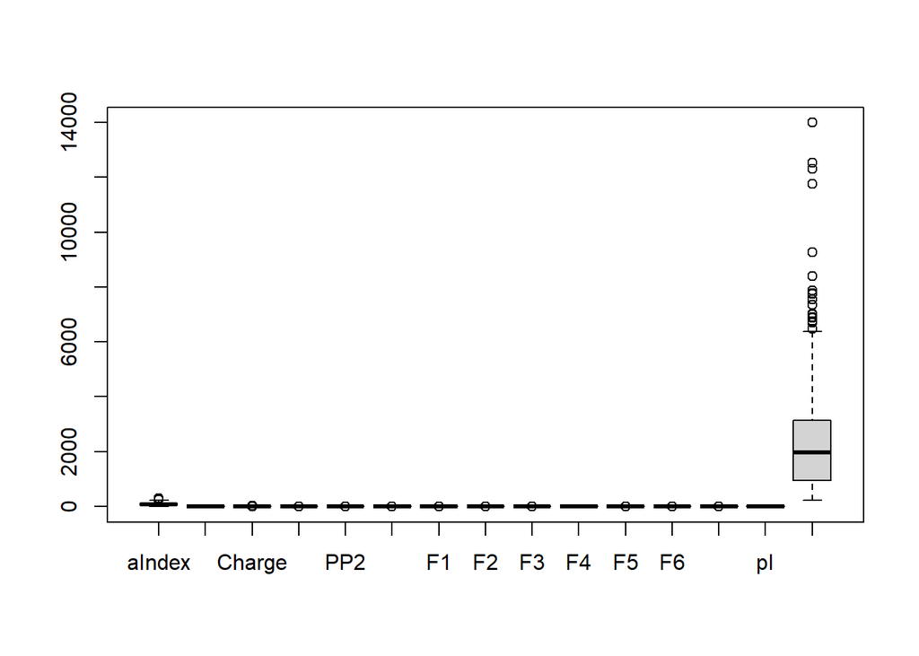

```r
datapep7= subset(peptideDescriptors7, select = -c(Name, sequence))
view(datapep7)
boxplot(datapep7)
```

```r
summary(datapep7)
```

```
##      aIndex           Boman            Charge              PP1
##  Min.   :  0.00   Min.   :-3.205   Min.   :-7.04703   Min.   :-0.93333
##  1st Qu.: 39.00   1st Qu.:-0.135   1st Qu.:-0.05919   1st Qu.:-0.39333
##  Median : 83.24   Median : 1.002   Median : 1.08291   Median :-0.22250
##  Mean   : 85.32   Mean   : 1.146   Mean   : 1.98262   Mean   :-0.19947
##  3rd Qu.:118.70   3rd Qu.: 2.381   3rd Qu.: 3.93922   3rd Qu.:-0.01913
##  Max.   :292.50   Max.   : 5.877   Max.   :12.93796   Max.   : 0.72200
##       PP2               PP3                F1                F2
##  Min.   :-0.8400   Min.   :-0.5808   Min.   :-1.3503   Min.   :-1.524500
##  1st Qu.:-0.3917   1st Qu.: 0.0300   1st Qu.:-0.3359   1st Qu.:-0.343308
##  Median :-0.2850   Median : 0.1300   Median :-0.1259   Median : 0.003128
##  Mean   :-0.2645   Mean   : 0.1077   Mean   :-0.1493   Mean   :-0.021113
##  3rd Qu.:-0.1617   3rd Qu.: 0.2333   3rd Qu.: 0.0285   3rd Qu.: 0.283111
##  Max.   : 0.3954   Max.   : 0.5116   Max.   : 0.8100   Max.   : 1.097889
##        F3                 F4                F5                F6
##  Min.   :-1.22467   Min.   :-0.6240   Min.   :-0.6773   Min.   :-1.202750
##  1st Qu.:-0.34502   1st Qu.: 0.0574   1st Qu.:-0.1222   1st Qu.:-0.184031
##  Median :-0.14217   Median : 0.3838   Median : 0.0190   Median :-0.001694
##  Mean   :-0.11161   Mean   : 0.3889   Mean   : 0.1487   Mean   :-0.004296
##  3rd Qu.: 0.08257   3rd Qu.: 0.7117   3rd Qu.: 0.2602   3rd Qu.: 0.219762
##  Max.   : 1.40100   Max.   : 1.3991   Max.   : 2.2947   Max.   : 1.146583
##  Hidrophobicity           pI               MW
##  Min.   :-1.09500   Min.   : 3.167   Min.   :  217.2
##  1st Qu.:-0.14875   1st Qu.: 6.100   1st Qu.:  940.0
##  Median : 0.01125   Median : 9.300   Median : 1958.3
##  Mean   : 0.01074   Mean   : 8.624   Mean   : 2401.6
##  3rd Qu.: 0.20500   3rd Qu.:11.103   3rd Qu.: 3131.9
##  Max.   : 0.98200   Max.   :13.278   Max.   :13992.9
```

## Normalizar y ver cambios

```r
pepscale7 = scale(datapep7)
summary(pepscale7)
```

```
##      aIndex             Boman              Charge             PP1
##  Min.   :-1.52218   Min.   :-2.58768   Min.   :-2.9524   Min.   :-2.76622
##  1st Qu.:-0.82635   1st Qu.:-0.76167   1st Qu.:-0.6676   1st Qu.:-0.73076
##  Median :-0.03698   Median :-0.08568   Median :-0.2942   Median :-0.08682
##  Mean   : 0.00000   Mean   : 0.00000   Mean   : 0.0000   Mean   : 0.00000
##  3rd Qu.: 0.59555   3rd Qu.: 0.73505   3rd Qu.: 0.6398   3rd Qu.: 0.67976
##  Max.   : 3.69651   Max.   : 2.81431   Max.   : 3.5821   Max.   : 3.47336
##       PP2               PP3                F1                 F2
##  Min.   :-2.8975   Min.   :-3.6544   Min.   :-4.04164   Min.   :-3.26103
##  1st Qu.:-0.6402   1st Qu.:-0.4126   1st Qu.:-0.62791   1st Qu.:-0.69888
##  Median :-0.1032   Median : 0.1181   Median : 0.07843   Median : 0.05258
##  Mean   : 0.0000   Mean   : 0.0000   Mean   : 0.00000   Mean   : 0.00000
##  3rd Qu.: 0.5178   3rd Qu.: 0.6665   3rd Qu.: 0.59814   3rd Qu.: 0.65990
##  Max.   : 3.3225   Max.   : 2.1432   Max.   : 3.22790   Max.   : 2.42725
##        F3                 F4                 F5                F6
##  Min.   :-3.11275   Min.   :-2.36198   Min.   :-1.7758   Min.   :-3.268752
##  1st Qu.:-0.65275   1st Qu.:-0.77308   1st Qu.:-0.5825   1st Qu.:-0.490224
##  Median :-0.08547   Median :-0.01198   Median :-0.2788   Median : 0.007095
##  Mean   : 0.00000   Mean   : 0.00000   Mean   : 0.0000   Mean   : 0.000000
##  3rd Qu.: 0.54305   3rd Qu.: 0.75263   3rd Qu.: 0.2397   3rd Qu.: 0.611112
##  Max.   : 4.23014   Max.   : 2.35559   Max.   : 4.6139   Max.   : 3.138993
##  Hidrophobicity            pI                MW
##  Min.   :-3.700781   Min.   :-1.9143   Min.   :-1.1227
##  1st Qu.:-0.533793   1st Qu.:-0.8853   1st Qu.:-0.7512
##  Median : 0.001708   Median : 0.2371   Median :-0.2279
##  Mean   : 0.000000   Mean   : 0.0000   Mean   : 0.0000
##  3rd Qu.: 0.650167   3rd Qu.: 0.8697   3rd Qu.: 0.3753
##  Max.   : 3.250695   Max.   : 1.6326   Max.   : 5.9575
```

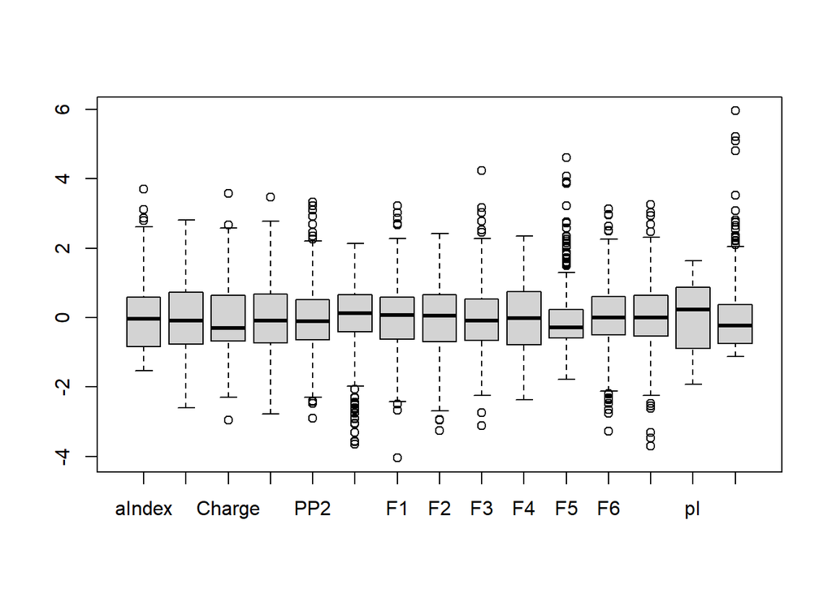

```r
boxplot(pepscale7)
```

## Calculo PCAs y obtención de archivo Excel de rotación

```r
PCApep7 = prcomp(pepscale7)
summary(PCApep7)
```

```
## Importance of components:
##                           PC1    PC2    PC3    PC4     PC5     PC6     PC7
## Standard deviation     2.0870 1.9214 1.4346 1.2736 1.07014 0.85621 0.60638
## Proportion of Variance 0.2904 0.2461 0.1372 0.1081 0.07635 0.04887 0.02451
## Cumulative Proportion  0.2904 0.5365 0.6737 0.7819 0.85820 0.90707 0.93158
##                            PC8     PC9    PC10    PC11    PC12    PC13    PC14
## Standard deviation     0.59410 0.48434 0.38612 0.33957 0.30317 0.21854 0.15252
## Proportion of Variance 0.02353 0.01564 0.00994 0.00769 0.00613 0.00318 0.00155
## Cumulative Proportion  0.95511 0.97075 0.98069 0.98838 0.99451 0.99769 0.99924
##                           PC15
## Standard deviation     0.10677
## Proportion of Variance 0.00076
## Cumulative Proportion  1.00000
```

```r
##write.csv2(PCApep7, "PCApep7.csv")##
```

## Para escoger el numero de PCAs

```r
stdev7= PCApep7$sdev
pr_var7 = stdev7^2
pr_var7[1:15]
```

```
##  [1] 4.35574751 3.69194881 2.05801035 1.62201751 1.14520616 0.73309730
##  [7] 0.36769831 0.35295897 0.23458543 0.14908928 0.11530689 0.09191428
## [13] 0.04775812 0.02326210 0.01139897
```

```r
prop_varex7 =pr_var7/sum(pr_var7)
prop_varex7[1:15]
```

```
##  [1] 0.2903831672 0.2461299204 0.1372006898 0.1081345008 0.0763470773
##  [6] 0.0488731537 0.0245132209 0.0235305983 0.0156390288 0.0099392856
## [11] 0.0076871258 0.0061276185 0.0031838748 0.0015508069 0.0007599314
```

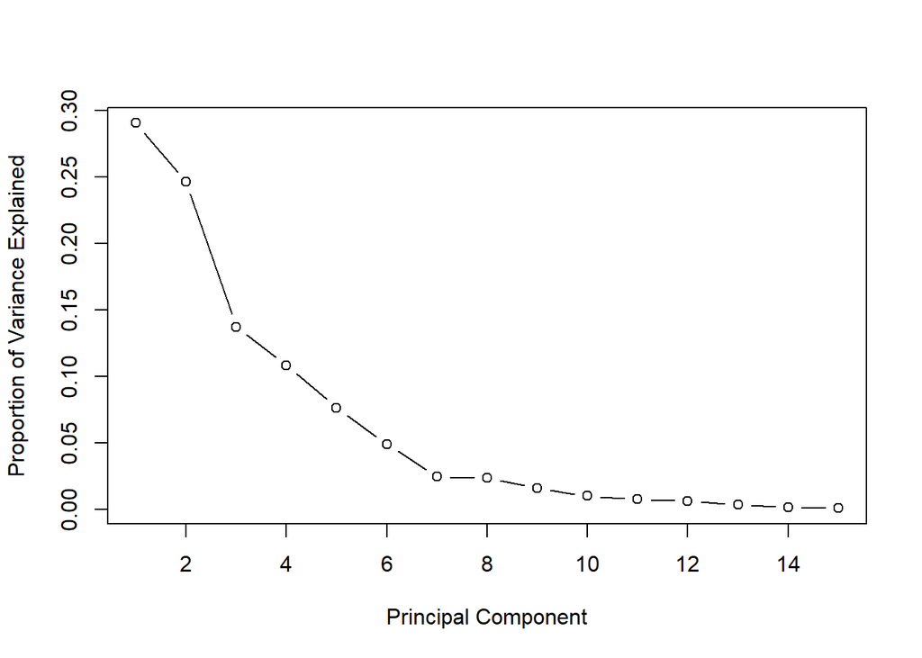

```r
plot(prop_varex7, xlab = "Principal Component",ylab = "Proportion of Variance Explained",type = "b")
```

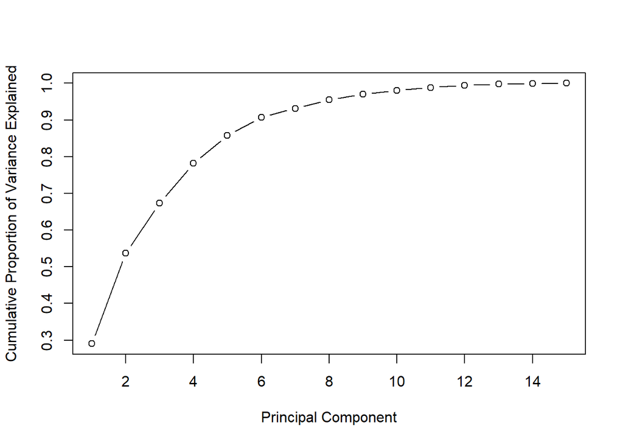

```r
plot(cumsum(prop_varex7), xlab = "Principal Component",ylab = "Cumulative Proportion of Variance Explained",type = "b")
```

## Determinar numero optimo de clusters por medio del metodo de “avarage silhouette”

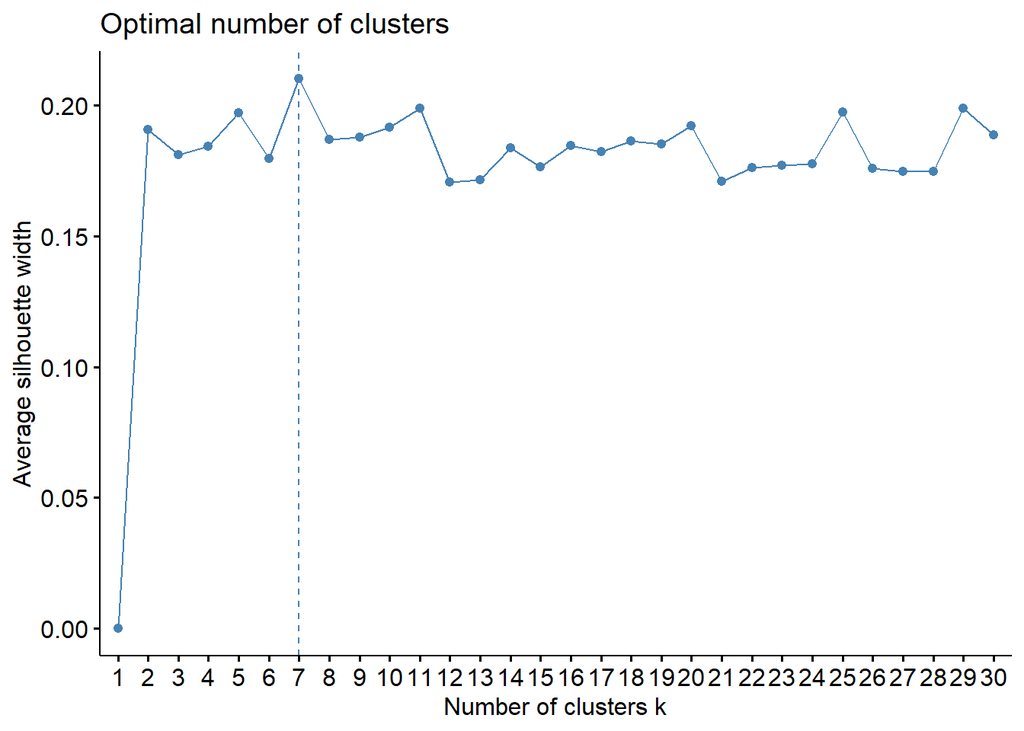

```r
fviz_nbclust(PCApep7$x[ ,1:15],kmeans,method = "silhouette", k.max = 30, iter.max=25)
```

## Graficar heatmap

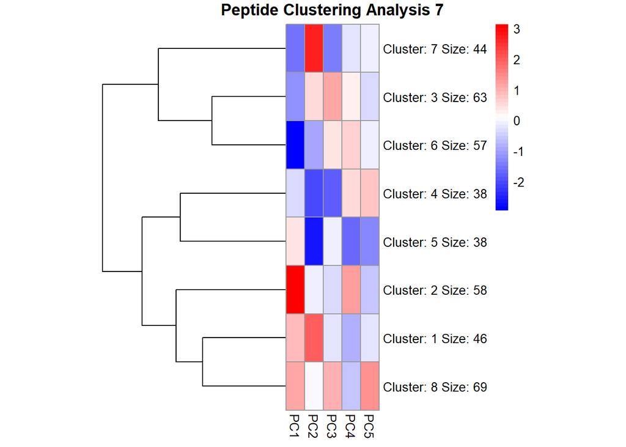

```r
cluster7pep= pheatmap(PCApep7$x[,1:5], kmeans_k = 8,cluster_cols = FALSE, treeheight_row = 150, cellwidth = 15, color = colorRampPalette(c("blue", "white", "red"))(50),main = "Peptide Clustering Analysis 7" )
```

```r
write.csv2 (cluster7pep$kmeans$cluster, file="clustermemberS7pep.csv")
```

# 8 clusters

## Leer archivo fuente, este es un excel, cambie un poco el codigo para usar lo que se

```r
Lista_calculo8 <- read_excel("C:/Users/javeb/Documents/R/TESIS/SESGADOS/CLUSTER_8.xlsx")
View(Lista_calculo8)
```

## Ahora a obtener los descriptores, verlo y guardarlos en un archivo Excel

```r
peptideDescriptors8 <- data.frame(
  Name = unlist(Lista_calculo8$Name),
  sequence = unlist(Lista_calculo8$Sequence),
  aIndex = aIndex(Lista_calculo8$Sequence),
  boman = boman(Lista_calculo8$Sequence),
  charge = charge(Lista_calculo8$Sequence, pH = 7, pKscale = "Sillero"),
  crucianiProperties = do.call(rbind.data.frame, crucianiProperties(Lista_calculo8$Sequence)),
  fasgaiVectors = do.call(rbind.data.frame, fasgaiVectors(Lista_calculo8$Sequence)),
  hydrophobicity = hydrophobicity(Lista_calculo8$Sequence, scale="Kidera"),
  pI = pI(Lista_calculo8$Sequence, pKscale="EMBOSS"),mw = mw(Lista_calculo8$Sequence))
colnames(peptideDescriptors8) <- c('Name','sequence', "aIndex", "Boman", "Charge", paste0('PP', 1:3), paste0('F', 1:6), "Hidrophobicity","pI", "MW")
view(peptideDescriptors8)
Tabla = subset(peptideDescriptors8, select = -c(sequence))
knitr::kable(Tabla, caption = "**Tabla 1.** Descriptores")
```

**Tabla 1.** Descriptores

| Name | aIndex | Boman | Charge | PP1 | PP2 | PP3 | F1 | F2 | F3 | F4 | F5 | F6 | Hidrophobicity | pI | MW |
| --- | --- | --- | --- | --- | --- | --- | --- | --- | --- | --- | --- | --- | --- | --- | --- |
| >Antiox_1 | 103.33333 | 0.5627778 | -1.0538969 | -0.3300000 | -0.4538889 | 0.0927778 | -0.1120556 | 0.0165000 | -0.3827222 | 0.8094444 | 0.1480000 | -0.2091667 | -0.0222222 | 4.258141 | 1805.0177 |
| >Antiox_2 | 37.69231 | 1.9584615 | 1.3324165 | -0.0876923 | -0.3384615 | 0.2761538 | -0.1028462 | -0.4549231 | -0.4346154 | -0.0149231 | 0.0067692 | -0.1303077 | -0.0753846 | 8.564801 | 1421.5558 |
| >Antiox_3 | 14.28571 | 3.9257143 | -4.0497356 | 0.3371429 | -0.4642857 | -0.5614286 | -0.7451429 | 0.2350000 | -0.2124286 | 0.1777143 | 0.5840000 | -1.0128571 | 0.3914286 | 3.331708 | 851.8218 |
| >Antiox_8 | 20.00000 | 2.6960000 | 0.3423275 | 0.2380000 | -0.4880000 | 0.3980000 | -0.1720000 | 0.0892000 | -0.5492000 | -0.1008000 | 0.0434000 | 0.0494000 | 0.2680000 | 7.714355 | 551.5595 |
| >Antiox_9 | 55.71429 | 2.1071429 | 0.9397985 | -0.2414286 | -0.1771429 | 0.0628571 | -0.5312857 | -0.4012857 | 0.0167143 | 0.1278571 | 0.9430000 | 0.2348571 | 0.0342857 | 9.348818 | 829.9542 |
| >Antiox_11 | 84.28571 | -0.1257143 | -0.0690935 | -0.4271429 | -0.4971429 | 0.0985714 | 0.1184286 | 0.0410000 | -0.6315714 | 0.3710000 | 0.5292857 | -0.2300000 | -0.2742857 | 5.922539 | 688.7966 |
| >Antiox_13 | 70.00000 | 3.8142857 | -2.0522868 | 0.3428571 | -0.4142857 | -0.3271429 | -0.6937143 | 0.7477143 | -0.1958571 | 0.4885714 | 0.1398571 | -0.5067143 | 0.6542857 | 3.927560 | 831.8778 |
| >Antiox_14 | 12.50000 | 3.5250000 | -3.0540422 | 0.1912500 | -0.5487500 | -0.3550000 | -0.5213750 | 0.0700000 | -0.4348750 | 0.0118750 | 0.4875000 | -0.7272500 | 0.3462500 | 3.380031 | 905.9318 |
| >Antiox_16 | 0.00000 | 4.1466667 | -0.8574335 | 0.2633333 | -0.6666667 | -0.0466667 | -0.5910000 | -0.7340000 | -0.7546667 | -0.1176667 | -0.4576667 | -0.9130000 | 0.3100000 | 5.292276 | 327.2968 |
| >Antiox_18 | 0.00000 | 5.6620000 | -0.8546791 | 0.7220000 | -0.4160000 | -0.0500000 | -0.8672000 | 0.3054000 | -0.2588000 | -0.1390000 | 0.0228000 | -0.2324000 | 0.9180000 | 5.454283 | 628.6396 |
| >Antiox_19 | 127.00000 | -0.6010000 | -0.8574335 | -0.5440000 | -0.5070000 | 0.0360000 | 0.1217000 | -0.4473000 | -0.5040000 | 0.9076000 | 0.1915000 | -0.7162000 | -0.3710000 | 5.292276 | 949.0743 |
| >Antiox_20 | 58.00000 | 1.9420000 | -1.0581935 | -0.0140000 | -0.7560000 | 0.0580000 | -0.6724000 | -0.6830000 | -0.7800000 | 0.6006000 | -0.2902000 | -0.2722000 | 0.2600000 | 3.749973 | 477.4716 |
| >Antiox_21 | 0.00000 | 3.0000000 | -1.0601915 | 0.5400000 | -0.0166667 | -0.4666667 | -0.2133333 | -0.7200000 | 0.9740000 | -0.3776667 | -0.6430000 | -0.3946667 | -0.1033333 | 3.749971 | 459.4558 |
| >Antiox_23 | 110.00000 | 2.9962500 | -3.0518889 | 0.2200000 | -0.4762500 | -0.3887500 | -0.4258750 | 0.4413750 | -0.2206250 | 0.5815000 | 0.0807500 | -0.8075000 | 0.2875000 | 3.424715 | 916.9400 |
| >Antiox_25 | 24.37500 | 2.9368750 | -1.8610398 | 0.0368750 | -0.4062500 | -0.0450000 | -0.4478125 | -0.2468125 | -0.3935000 | -0.0433750 | 0.6785000 | -0.2118125 | 0.1493750 | 4.421435 | 1799.9325 |
| >Antiox_26 | 55.71429 | 3.5728571 | 0.1437108 | 0.2028571 | -0.1128571 | 0.0614286 | -0.3172857 | -0.0554286 | 0.1348571 | 0.0510000 | 0.5651429 | 0.0808571 | 0.1900000 | 7.543349 | 900.9896 |
| >Antiox_34 | 72.50000 | 0.1612500 | 0.9404096 | -0.3812500 | -0.3400000 | 0.1425000 | -0.5760000 | -0.4768750 | -0.2008750 | 0.4083750 | 0.8936250 | 0.1082500 | -0.1487500 | 9.700016 | 860.0209 |
| >Antiox_35 | 78.00000 | -0.8440000 | 0.9404096 | -0.6180000 | -0.3220000 | 0.2160000 | -0.2940000 | 0.0024000 | -0.2030000 | 0.7898000 | -0.2876000 | 0.0868000 | -0.1120000 | 9.700016 | 520.6292 |
| >Antiox_36 | 66.66667 | -1.5200000 | -0.0591925 | -0.9333333 | -0.8400000 | 0.3700000 | 0.0696667 | -0.1923333 | -1.2246667 | 1.3343333 | -0.3296667 | -0.7820000 | -0.2333333 | 6.099982 | 217.2247 |
| >Antiox_37 | 70.00000 | 1.4942857 | 0.9407975 | -0.2728571 | -0.1142857 | 0.0900000 | -0.0671429 | -0.2320000 | 0.0021429 | 0.3212857 | 0.3470000 | -0.0345714 | -0.1257143 | 10.549999 | 826.9534 |
| >Antiox_38 | 40.83333 | 1.0450000 | 0.9407975 | -0.4858333 | -0.5200000 | 0.2333333 | -0.2312500 | -1.0610000 | -0.7300000 | 0.6150833 | 0.6420833 | -0.4115833 | -0.0550000 | 10.549999 | 1107.2344 |
| >Antiox_40 | 0.00000 | 3.4300000 | -0.0659512 | 0.1300000 | -0.2000000 | 0.1300000 | -0.2395000 | -0.2256667 | -0.3216667 | -0.2906667 | -0.3861667 | 0.0555000 | 0.1133333 | 6.232445 | 736.8003 |
| >Antiox_41 | 65.00000 | -0.4950000 | -1.0560402 | -0.5633333 | -0.4050000 | -0.1500000 | 0.0468333 | -0.6111667 | -0.3663333 | 0.7368333 | 0.4315000 | -0.8098333 | -0.4050000 | 3.849974 | 618.6872 |
| >Antiox_43 | 0.00000 | 3.2600000 | 0.9407975 | -0.4425000 | -0.4425000 | 0.4750000 | -0.5115000 | -1.5245000 | -0.8400000 | 0.5005000 | 0.3912500 | -0.1680000 | 0.2000000 | 10.549999 | 385.4232 |
| >Antiox_48 | 0.00000 | 1.2587500 | -1.0560402 | -0.3062500 | -0.6275000 | 0.0650000 | -0.3805000 | -1.2580000 | -0.8231250 | 0.3711250 | 1.2461250 | -0.7206250 | -0.0175000 | 3.849974 | 754.7948 |
| >Antiox_50 | 156.00000 | -2.2533333 | -0.0591925 | -0.7906667 | -0.3973333 | 0.0573333 | 0.4075333 | -0.5971333 | -0.3288667 | 1.1912667 | 0.3588000 | -0.5916667 | -0.6606667 | 6.099982 | 1410.7193 |
| >Antiox_52 | 107.00000 | -0.3820000 | 0.9407975 | -0.7120000 | -0.2620000 | 0.0680000 | 0.0103000 | -0.8264000 | -0.1505000 | 0.4214000 | 0.8650000 | -0.1011000 | -0.4070000 | 10.549999 | 1052.2846 |
| >Antiox_54 | 0.00000 | 3.5614286 | 0.1411696 | 0.3600000 | -0.4457143 | 0.2571429 | -0.5458571 | -0.5974286 | -0.3405714 | 0.0950000 | -0.3295714 | -0.2041429 | 0.4157143 | 7.541473 | 792.8033 |
| >Antiox_55 | 136.00000 | -1.4660000 | -0.0591925 | -0.6380000 | -0.4880000 | 0.0820000 | -0.1552000 | -0.6068000 | -0.4196000 | 0.8744000 | 0.6312000 | -0.1560000 | -0.3560000 | 6.099982 | 485.5809 |
| >Antiox_56 | 0.00000 | 1.5914286 | -0.6566735 | -0.1500000 | -0.2214286 | -0.1428571 | 0.0062857 | -0.4561429 | -0.0257143 | -0.2771429 | 0.3570000 | -0.5297143 | -0.3428571 | 6.496521 | 855.9078 |

[output cut: 254 more lines]

```r
write.csv2(peptideDescriptors8, "Descriptores8.csv")
```

## Quito primera y segunda fila y exploratorio de datos

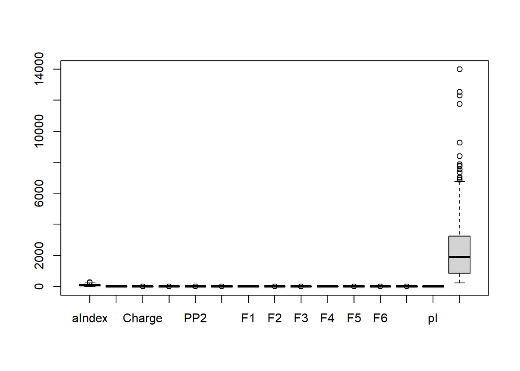

```r
datapep8= subset(peptideDescriptors8, select = -c(Name, sequence))
view(datapep8)
boxplot(datapep8)
```

```r
summary(datapep8)
```

```
##      aIndex           Boman             Charge              PP1
##  Min.   :  0.00   Min.   :-2.3012   Min.   :-7.04703   Min.   :-0.93333
##  1st Qu.: 34.85   1st Qu.:-0.3210   1st Qu.:-0.06019   1st Qu.:-0.43111
##  Median : 72.50   Median : 0.9607   Median : 0.94041   Median :-0.24452
##  Mean   : 81.00   Mean   : 1.0498   Mean   : 1.20211   Mean   :-0.21726
##  3rd Qu.:116.28   3rd Qu.: 2.1352   3rd Qu.: 2.93961   3rd Qu.:-0.01885
##  Max.   :260.00   Max.   : 5.6620   Max.   : 9.85895   Max.   : 0.72200
##       PP2               PP3                 F1                 F2
##  Min.   :-0.8400   Min.   :-0.58083   Min.   :-0.94020   Min.   :-1.5245
##  1st Qu.:-0.4208   1st Qu.: 0.03282   1st Qu.:-0.36375   1st Qu.:-0.4661
##  Median :-0.3384   Median : 0.11720   Median :-0.14325   Median :-0.1378
##  Mean   :-0.3344   Mean   : 0.09161   Mean   :-0.16483   Mean   :-0.1095
##  3rd Qu.:-0.2397   3rd Qu.: 0.20224   3rd Qu.: 0.03926   3rd Qu.: 0.2354
##  Max.   : 0.2233   Max.   : 0.47500   Max.   : 0.49112   Max.   : 0.9232
##        F3                 F4                 F5                 F6
##  Min.   :-1.22467   Min.   :-0.55425   Min.   :-0.64300   Min.   :-1.20275
##  1st Qu.:-0.43088   1st Qu.: 0.02284   1st Qu.:-0.12453   1st Qu.:-0.23433
##  Median :-0.22258   Median : 0.37106   Median : 0.05669   Median :-0.06436
##  Mean   :-0.23160   Mean   : 0.39435   Mean   : 0.20082   Mean   :-0.11257
##  3rd Qu.:-0.05808   3rd Qu.: 0.78253   3rd Qu.: 0.33586   3rd Qu.: 0.06765
##  Max.   : 0.97400   Max.   : 1.39913   Max.   : 2.29467   Max.   : 0.77300
##  Hidrophobicity            pI               MW
##  Min.   :-1.023333   Min.   : 3.167   Min.   :  217.2
##  1st Qu.:-0.152500   1st Qu.: 6.100   1st Qu.:  855.7
##  Median :-0.022299   Median : 7.832   Median : 1884.5
##  Mean   :-0.005961   Mean   : 8.019   Mean   : 2474.2
##  3rd Qu.: 0.141274   3rd Qu.:10.550   3rd Qu.: 3245.1
##  Max.   : 0.982000   Max.   :13.278   Max.   :13992.9
```

## Normalizar y ver cambios

```r
pepscale8 = scale(datapep8)
summary(pepscale8)
```

```
##      aIndex            Boman              Charge             PP1
##  Min.   :-1.3885   Min.   :-1.99939   Min.   :-3.2777   Min.   :-2.52044
##  1st Qu.:-0.7911   1st Qu.:-0.81789   1st Qu.:-0.5016   1st Qu.:-0.75272
##  Median :-0.1456   Median :-0.05316   Median :-0.1040   Median :-0.09597
##  Mean   : 0.0000   Mean   : 0.00000   Mean   : 0.0000   Mean   : 0.00000
##  3rd Qu.: 0.6049   3rd Qu.: 0.64763   3rd Qu.: 0.6904   3rd Qu.: 0.69836
##  Max.   : 3.0688   Max.   : 2.75191   Max.   : 3.4397   Max.   : 3.30599
##       PP2                PP3                F1                 F2
##  Min.   :-3.11645   Min.   :-3.8234   Min.   :-2.62994   Min.   :-2.9059
##  1st Qu.:-0.53272   1st Qu.:-0.3343   1st Qu.:-0.67472   1st Qu.:-0.7323
##  Median :-0.02447   Median : 0.1455   Median : 0.07318   Median :-0.0582
##  Mean   : 0.00000   Mean   : 0.0000   Mean   : 0.00000   Mean   : 0.0000
##  3rd Qu.: 0.58354   3rd Qu.: 0.6290   3rd Qu.: 0.69223   3rd Qu.: 0.7081
##  Max.   : 3.43754   Max.   : 2.1799   Max.   : 2.22487   Max.   : 2.1206
##        F3                F4                 F5                F6
##  Min.   :-3.2157   Min.   :-2.07612   Min.   :-1.6259   Min.   :-3.6004
##  1st Qu.:-0.6453   1st Qu.:-0.81309   1st Qu.:-0.6269   1st Qu.:-0.4021
##  Median : 0.0292   Median :-0.05096   Median :-0.2777   Median : 0.1592
##  Mean   : 0.0000   Mean   : 0.00000   Mean   : 0.0000   Mean   : 0.0000
##  3rd Qu.: 0.5619   3rd Qu.: 0.84958   3rd Qu.: 0.2602   3rd Qu.: 0.5952
##  Max.   : 3.9039   Max.   : 2.19909   Max.   : 4.0346   Max.   : 2.9247
##  Hidrophobicity           pI                 MW
##  Min.   :-3.54134   Min.   :-1.87120   Min.   :-1.0124
##  1st Qu.:-0.51008   1st Qu.:-0.73998   1st Qu.:-0.7260
##  Median :-0.05687   Median :-0.07212   Median :-0.2645
##  Mean   : 0.00000   Mean   : 0.00000   Mean   : 0.0000
##  3rd Qu.: 0.51251   3rd Qu.: 0.97605   3rd Qu.: 0.3458
##  Max.   : 3.43897   Max.   : 2.02811   Max.   : 5.1670
```

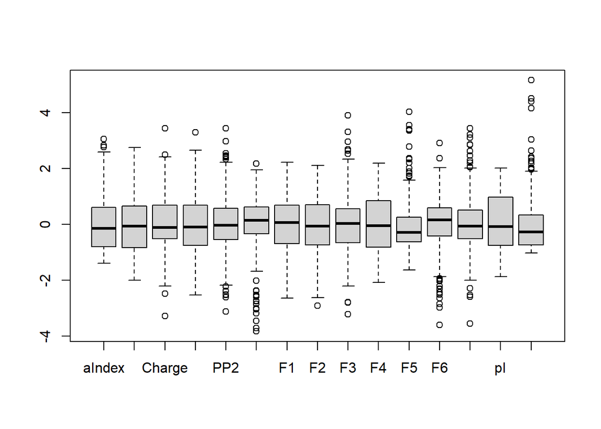

```r
boxplot(pepscale8)
```

## Calculo PCAs y obtención de archivo Excel de rotación

```r
PCApep8 = prcomp(pepscale8)
summary(PCApep8)
```

```
## Importance of components:
##                           PC1    PC2    PC3    PC4     PC5     PC6     PC7
## Standard deviation     2.3116 1.6147 1.4379 1.3565 1.01210 0.83418 0.68480
## Proportion of Variance 0.3563 0.1738 0.1378 0.1227 0.06829 0.04639 0.03126
## Cumulative Proportion  0.3563 0.5301 0.6679 0.7906 0.85886 0.90525 0.93652
##                            PC8     PC9   PC10    PC11    PC12   PC13    PC14
## Standard deviation     0.54202 0.46211 0.3969 0.34955 0.27751 0.2257 0.15537
## Proportion of Variance 0.01959 0.01424 0.0105 0.00815 0.00513 0.0034 0.00161
## Cumulative Proportion  0.95610 0.97034 0.9808 0.98899 0.99412 0.9975 0.99912
##                           PC15
## Standard deviation     0.11466
## Proportion of Variance 0.00088
## Cumulative Proportion  1.00000
```

```r
##write.csv2(PCApep8, "PCApep8.csv")##
```

## Para escoger el numero de PCAs

```r
stdev8= PCApep8$sdev
pr_var8 = stdev8^2
pr_var8[1:15]
```

```
##  [1] 5.34368139 2.60717628 2.06765988 1.84007240 1.02434480 0.69585378
##  [7] 0.46894457 0.29378616 0.21354851 0.15752055 0.12218739 0.07701185
## [13] 0.05092752 0.02413835 0.01314658
```

```r
prop_varex8 =pr_var8/sum(pr_var8)
prop_varex8[1:15]
```

```
##  [1] 0.3562454261 0.1738117522 0.1378439917 0.1226714931 0.0682896533
##  [6] 0.0463902522 0.0312629716 0.0195857440 0.0142365673 0.0105013697
## [11] 0.0081458258 0.0051341230 0.0033951682 0.0016092232 0.0008764386
```

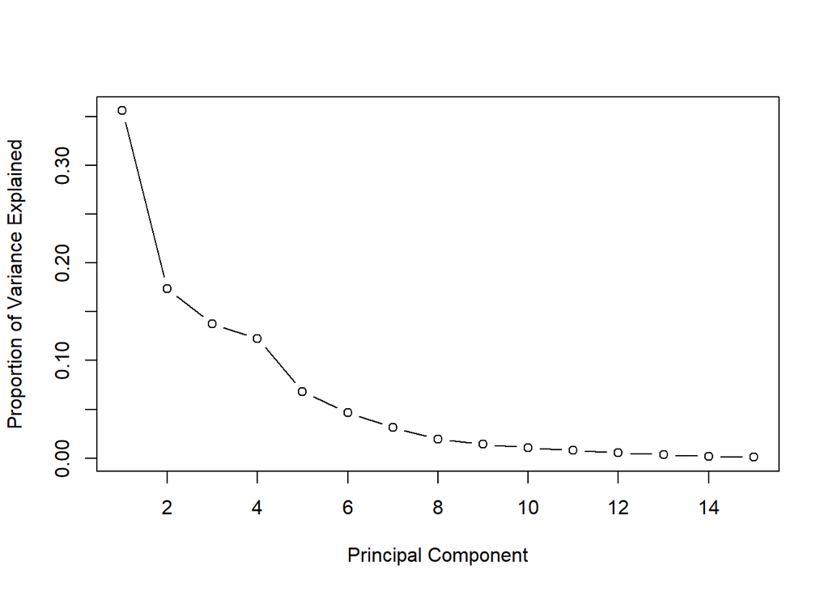

```r
plot(prop_varex8, xlab = "Principal Component",ylab = "Proportion of Variance Explained",type = "b")
```

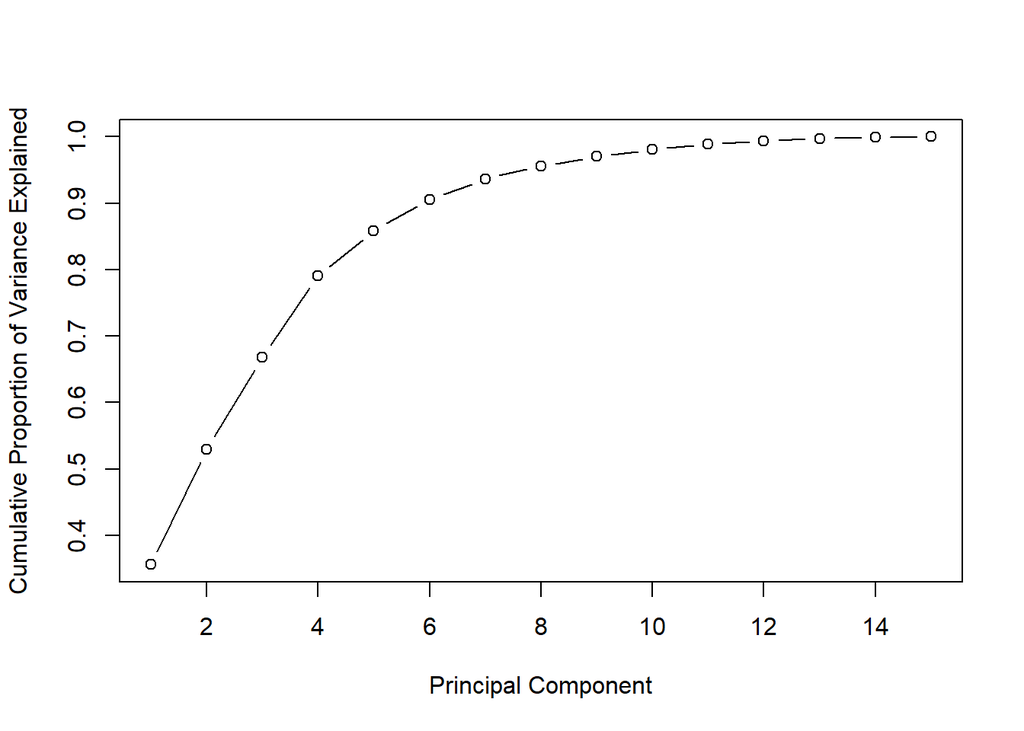

```r
plot(cumsum(prop_varex8), xlab = "Principal Component",ylab = "Cumulative Proportion of Variance Explained",type = "b")
```

## Determinar numero optimo de clusters por medio del metodo de “avarage silhouette”

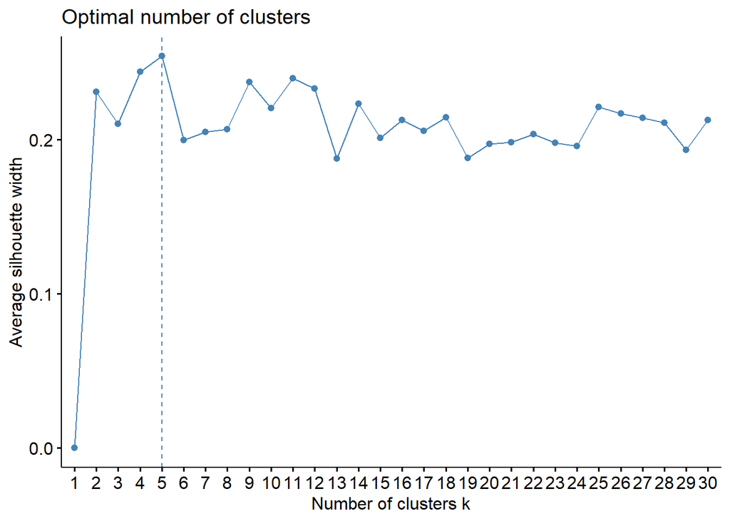

```r
fviz_nbclust(PCApep8$x[ ,1:15],kmeans,method = "silhouette", k.max = 30, iter.max=25)
```

## Graficar heatmap

## Heatmap de 8 clusters

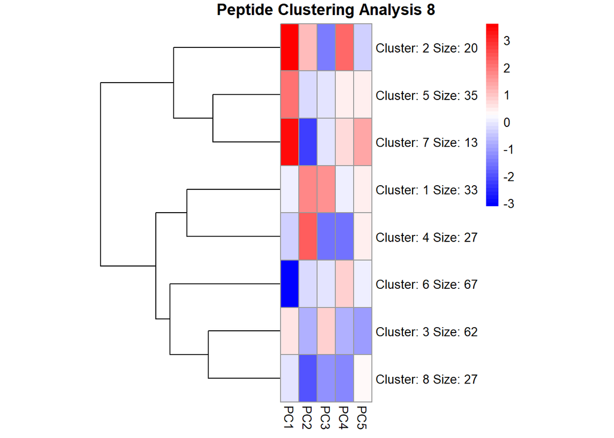

```r
cluster8pep= pheatmap(PCApep8$x[,1:5], kmeans_k = 8,cluster_cols = FALSE, treeheight_row = 150, cellwidth = 15, color = colorRampPalette(c("blue", "white", "red"))(50),main = "Peptide Clustering Analysis 8" )
```

```r
write.csv2 (cluster8pep$kmeans$cluster, file="clustermemberS8pep.csv")
```

# 9 clusters

## Leer archivo fuente, este es un excel, cambie un poco el codigo para usar lo que se

```r
Lista_calculo9 <- read_excel("C:/Users/javeb/Documents/R/TESIS/SESGADOS/CLUSTER_9.xlsx")
View(Lista_calculo9)
```

## Ahora a obtener los descriptores, verlo y guardarlos en un archivo Excel

```r
peptideDescriptors9 <- data.frame(
  Name = unlist(Lista_calculo9$Name),
  sequence = unlist(Lista_calculo9$Sequence),
  aIndex = aIndex(Lista_calculo9$Sequence),
  boman = boman(Lista_calculo9$Sequence),
  charge = charge(Lista_calculo9$Sequence, pH = 7, pKscale = "Sillero"),
  crucianiProperties = do.call(rbind.data.frame, crucianiProperties(Lista_calculo9$Sequence)),
  fasgaiVectors = do.call(rbind.data.frame, fasgaiVectors(Lista_calculo9$Sequence)),
  hydrophobicity = hydrophobicity(Lista_calculo9$Sequence, scale="Kidera"),
  pI = pI(Lista_calculo9$Sequence, pKscale="EMBOSS"),mw = mw(Lista_calculo9$Sequence))
colnames(peptideDescriptors9) <- c('Name','sequence', "aIndex", "Boman", "Charge", paste0('PP', 1:3), paste0('F', 1:6), "Hidrophobicity","pI", "MW")
view(peptideDescriptors9)
Tabla = subset(peptideDescriptors9, select = -c(sequence))
knitr::kable(Tabla, caption = "**Tabla 1.** Descriptores")
```

**Tabla 1.** Descriptores

| Name | aIndex | Boman | Charge | PP1 | PP2 | PP3 | F1 | F2 | F3 | F4 | F5 | F6 | Hidrophobicity | pI | MW |
| --- | --- | --- | --- | --- | --- | --- | --- | --- | --- | --- | --- | --- | --- | --- | --- |
| >Antiox_1 | 103.33333 | 0.5627778 | -1.0538969 | -0.3300000 | -0.4538889 | 0.0927778 | -0.1120556 | 0.0165000 | -0.3827222 | 0.8094444 | 0.1480000 | -0.2091667 | -0.0222222 | 4.258141 | 1805.0177 |
| >Antiox_2 | 37.69231 | 1.9584615 | 1.3324165 | -0.0876923 | -0.3384615 | 0.2761538 | -0.1028462 | -0.4549231 | -0.4346154 | -0.0149231 | 0.0067692 | -0.1303077 | -0.0753846 | 8.564801 | 1421.5558 |
| >Antiox_6 | 97.50000 | 0.7975000 | 1.9364036 | -0.1325000 | -0.0993750 | 0.0862500 | -0.0538125 | -0.2690625 | 0.3640000 | 0.2704375 | 0.2588125 | 0.2653125 | -0.0962500 | 9.634027 | 1961.2909 |
| >Antiox_8 | 20.00000 | 2.6960000 | 0.3423275 | 0.2380000 | -0.4880000 | 0.3980000 | -0.1720000 | 0.0892000 | -0.5492000 | -0.1008000 | 0.0434000 | 0.0494000 | 0.2680000 | 7.714355 | 551.5595 |
| >Antiox_11 | 84.28571 | -0.1257143 | -0.0690935 | -0.4271429 | -0.4971429 | 0.0985714 | 0.1184286 | 0.0410000 | -0.6315714 | 0.3710000 | 0.5292857 | -0.2300000 | -0.2742857 | 5.922539 | 688.7966 |
| >Antiox_15 | 65.00000 | 0.3666667 | -1.0601915 | -0.1733333 | -0.3366667 | -0.1100000 | 0.0250000 | -0.9116667 | 0.0521667 | 0.5381667 | -0.6038333 | -0.6028333 | -0.2883333 | 3.749971 | 686.7190 |
| >Antiox_16 | 0.00000 | 4.1466667 | -0.8574335 | 0.2633333 | -0.6666667 | -0.0466667 | -0.5910000 | -0.7340000 | -0.7546667 | -0.1176667 | -0.4576667 | -0.9130000 | 0.3100000 | 5.292276 | 327.2968 |
| >Antiox_18 | 0.00000 | 5.6620000 | -0.8546791 | 0.7220000 | -0.4160000 | -0.0500000 | -0.8672000 | 0.3054000 | -0.2588000 | -0.1390000 | 0.0228000 | -0.2324000 | 0.9180000 | 5.454283 | 628.6396 |
| >Antiox_19 | 127.00000 | -0.6010000 | -0.8574335 | -0.5440000 | -0.5070000 | 0.0360000 | 0.1217000 | -0.4473000 | -0.5040000 | 0.9076000 | 0.1915000 | -0.7162000 | -0.3710000 | 5.292276 | 949.0743 |
| >Antiox_20 | 58.00000 | 1.9420000 | -1.0581935 | -0.0140000 | -0.7560000 | 0.0580000 | -0.6724000 | -0.6830000 | -0.7800000 | 0.6006000 | -0.2902000 | -0.2722000 | 0.2600000 | 3.749973 | 477.4716 |
| >Antiox_25 | 24.37500 | 2.9368750 | -1.8610398 | 0.0368750 | -0.4062500 | -0.0450000 | -0.4478125 | -0.2468125 | -0.3935000 | -0.0433750 | 0.6785000 | -0.2118125 | 0.1493750 | 4.421435 | 1799.9325 |
| >Antiox_26 | 55.71429 | 3.5728571 | 0.1437108 | 0.2028571 | -0.1128571 | 0.0614286 | -0.3172857 | -0.0554286 | 0.1348571 | 0.0510000 | 0.5651429 | 0.0808571 | 0.1900000 | 7.543349 | 900.9896 |
| >Antiox_35 | 78.00000 | -0.8440000 | 0.9404096 | -0.6180000 | -0.3220000 | 0.2160000 | -0.2940000 | 0.0024000 | -0.2030000 | 0.7898000 | -0.2876000 | 0.0868000 | -0.1120000 | 9.700016 | 520.6292 |
| >Antiox_36 | 66.66667 | -1.5200000 | -0.0591925 | -0.9333333 | -0.8400000 | 0.3700000 | 0.0696667 | -0.1923333 | -1.2246667 | 1.3343333 | -0.3296667 | -0.7820000 | -0.2333333 | 6.099982 | 217.2247 |
| >Antiox_37 | 70.00000 | 1.4942857 | 0.9407975 | -0.2728571 | -0.1142857 | 0.0900000 | -0.0671429 | -0.2320000 | 0.0021429 | 0.3212857 | 0.3470000 | -0.0345714 | -0.1257143 | 10.549999 | 826.9534 |
| >Antiox_40 | 0.00000 | 3.4300000 | -0.0659512 | 0.1300000 | -0.2000000 | 0.1300000 | -0.2395000 | -0.2256667 | -0.3216667 | -0.2906667 | -0.3861667 | 0.0555000 | 0.1133333 | 6.232445 | 736.8003 |
| >Antiox_41 | 65.00000 | -0.4950000 | -1.0560402 | -0.5633333 | -0.4050000 | -0.1500000 | 0.0468333 | -0.6111667 | -0.3663333 | 0.7368333 | 0.4315000 | -0.8098333 | -0.4050000 | 3.849974 | 618.6872 |
| >Antiox_44 | 83.57143 | 0.4300000 | -0.0560502 | -0.3557143 | -0.1550000 | -0.0814286 | 0.0213571 | -0.1697857 | 0.1147143 | 0.3172143 | 0.4226429 | -0.1179286 | -0.2964286 | 6.410139 | 1646.9090 |
| >Antiox_54 | 0.00000 | 3.5614286 | 0.1411696 | 0.3600000 | -0.4457143 | 0.2571429 | -0.5458571 | -0.5974286 | -0.3405714 | 0.0950000 | -0.3295714 | -0.2041429 | 0.4157143 | 7.541473 | 792.8033 |
| >Antiox_56 | 0.00000 | 1.5914286 | -0.6566735 | -0.1500000 | -0.2214286 | -0.1428571 | 0.0062857 | -0.4561429 | -0.0257143 | -0.2771429 | 0.3570000 | -0.5297143 | -0.3428571 | 6.496521 | 855.9078 |
| >Antiox_59 | 0.00000 | 1.4625000 | 0.1405685 | 0.1425000 | -0.1200000 | 0.1650000 | 0.1125000 | 0.0255000 | 0.2317500 | -0.5542500 | -0.1980000 | 0.0312500 | -0.1475000 | 7.542328 | 536.6031 |
| >Antiox_63 | 260.00000 | -1.4300000 | 0.9404096 | -0.4133333 | 0.0266667 | 0.1933333 | 0.4456667 | 0.7453333 | 0.5990000 | 0.9903333 | 0.0570000 | 0.4810000 | -0.0566667 | 9.700016 | 372.5081 |
| >Antiox_65 | 120.00000 | -0.1476923 | 0.9407975 | -0.5430769 | -0.4000000 | 0.1638462 | 0.0543846 | -0.3433077 | -0.3396154 | 0.5430769 | -0.0232308 | -0.0020769 | -0.1192308 | 10.549999 | 1298.5662 |
| >Antiox_66 | 163.33333 | -0.3933333 | 0.9404096 | -0.4333333 | -0.2366667 | 0.3766667 | 0.1146667 | 0.6430000 | 0.0283333 | 0.8180000 | -0.1006667 | 0.3280000 | 0.2200000 | 9.700016 | 330.4275 |
| >Antiox_68 | 0.00000 | 2.3450000 | -0.0564381 | -0.0300000 | -0.0900000 | -0.1600000 | -0.4740000 | 0.0537500 | 0.1740000 | 0.0980000 | 1.0285000 | -0.3172500 | 0.1725000 | 6.408784 | 519.5981 |
| >Antiox_69 | 0.00000 | 5.4225000 | 0.1453109 | 0.3875000 | -0.2375000 | 0.0375000 | -0.6875000 | -0.0637500 | -0.1145000 | -0.0697500 | -0.2121250 | -0.0971250 | 0.6312500 | 7.550345 | 1002.0543 |
| >Antiox_70 | 0.00000 | 3.2142857 | 2.1312586 | 0.0271429 | -0.1442857 | 0.4042857 | -0.1255714 | -0.1348571 | -0.2245714 | -0.2768571 | -0.2864286 | 0.5674286 | 0.2628571 | 9.834312 | 847.9903 |
| >Antiox_73 | 118.00000 | 0.7300000 | 0.9404096 | -0.2800000 | -0.3920000 | 0.2800000 | -0.1564000 | 0.4806000 | -0.2916000 | 0.9228000 | -0.0092000 | -0.1578000 | 0.1740000 | 9.700016 | 515.6101 |
| >Antiox_76 | 78.00000 | 3.7713333 | 3.3450519 | 0.2013333 | 0.0226667 | 0.2440000 | -0.1838000 | 0.3384667 | 0.2467333 | 0.1880000 | 0.0677333 | 0.4902667 | 0.2666667 | 12.222617 | 1952.2521 |
| >Antiox_78 | 130.00000 | -0.4000000 | 0.1415675 | -0.3700000 | -0.3600000 | 0.2066667 | 0.2416667 | -0.2100000 | -0.3256667 | 0.5753333 | -0.1926667 | -0.3726667 | -0.3266667 | 7.550325 | 325.3676 |

[output cut: 306 more lines]

```r
write.csv2(peptideDescriptors9, "Descriptores9.csv")
```

## Quito primera y segunda fila y exploratorio de datos

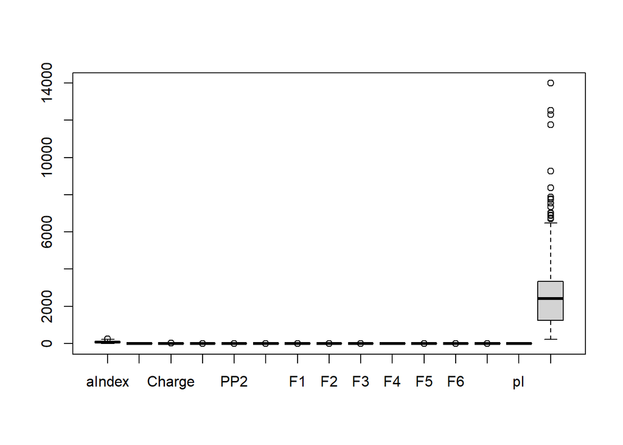

```r
datapep9= subset(peptideDescriptors9, select = -c(Name, sequence))
view(datapep9)
boxplot(datapep9)
```

```r
summary(datapep9)
```

```
##      aIndex           Boman             Charge              PP1
##  Min.   :  0.00   Min.   :-1.9725   Min.   :-4.33878   Min.   :-0.93333
##  1st Qu.: 38.37   1st Qu.: 0.1587   1st Qu.:-0.05644   1st Qu.:-0.32866
##  Median : 78.00   Median : 1.2887   Median : 2.14107   Median :-0.18474
##  Mean   : 83.01   Mean   : 1.3357   Mean   : 2.52397   Mean   :-0.16703
##  3rd Qu.:118.00   3rd Qu.: 2.4861   3rd Qu.: 4.92911   3rd Qu.:-0.01358
##  Max.   :260.00   Max.   : 5.8771   Max.   :12.93796   Max.   : 0.72200
##       PP2               PP3                 F1                 F2
##  Min.   :-0.8400   Min.   :-0.51500   Min.   :-1.35033   Min.   :-1.11275
##  1st Qu.:-0.3891   1st Qu.: 0.07344   1st Qu.:-0.31383   1st Qu.:-0.23842
##  Median :-0.2932   Median : 0.16621   Median :-0.11848   Median : 0.03219
##  Mean   :-0.2670   Mean   : 0.14995   Mean   :-0.15659   Mean   : 0.02273
##  3rd Qu.:-0.1651   3rd Qu.: 0.25402   3rd Qu.: 0.01039   3rd Qu.: 0.28592
##  Max.   : 0.3954   Max.   : 0.51158   Max.   : 0.44567   Max.   : 0.92316
##        F3                 F4                 F5                 F6
##  Min.   :-1.22467   Min.   :-0.55425   Min.   :-0.60383   Min.   :-1.20275
##  1st Qu.:-0.37274   1st Qu.: 0.02603   1st Qu.:-0.14118   1st Qu.:-0.12733
##  Median :-0.14613   Median : 0.38165   Median :-0.01496   Median : 0.02524
##  Mean   :-0.13146   Mean   : 0.38529   Mean   : 0.03174   Mean   : 0.05760
##  3rd Qu.: 0.05543   3rd Qu.: 0.73015   3rd Qu.: 0.15166   3rd Qu.: 0.26569
##  Max.   : 0.88323   Max.   : 1.39913   Max.   : 1.41645   Max.   : 1.14658
##  Hidrophobicity           pI               MW
##  Min.   :-0.51667   Min.   : 3.492   Min.   :  217.2
##  1st Qu.:-0.09653   1st Qu.: 6.437   1st Qu.: 1251.6
##  Median : 0.03760   Median : 9.683   Median : 2424.4
##  Mean   : 0.07218   Mean   : 8.996   Mean   : 2711.5
##  3rd Qu.: 0.22908   3rd Qu.:11.278   3rd Qu.: 3338.2
##  Max.   : 0.98200   Max.   :13.278   Max.   :13992.9
```

## Normalizar y ver cambios

```r
pepscale9 = scale(datapep9)
summary(pepscale9)
```

```
##      aIndex            Boman              Charge             PP1
##  Min.   :-1.5332   Min.   :-2.08510   Min.   :-2.2852   Min.   :-3.21974
##  1st Qu.:-0.8246   1st Qu.:-0.74184   1st Qu.:-0.8592   1st Qu.:-0.67912
##  Median :-0.0926   Median :-0.02966   Median :-0.1275   Median :-0.07441
##  Mean   : 0.0000   Mean   : 0.00000   Mean   : 0.0000   Mean   : 0.00000
##  3rd Qu.: 0.6462   3rd Qu.: 0.72508   3rd Qu.: 0.8009   3rd Qu.: 0.64475
##  Max.   : 3.2689   Max.   : 2.86237   Max.   : 3.4677   Max.   : 3.73538
##       PP2               PP3                F1                F2
##  Min.   :-2.8798   Min.   :-4.4205   Min.   :-4.4561   Min.   :-2.90786
##  1st Qu.:-0.6138   1st Qu.:-0.5086   1st Qu.:-0.5870   1st Qu.:-0.66879
##  Median :-0.1314   Median : 0.1082   Median : 0.1422   Median : 0.02423
##  Mean   : 0.0000   Mean   : 0.0000   Mean   : 0.0000   Mean   : 0.00000
##  3rd Qu.: 0.5122   3rd Qu.: 0.6919   3rd Qu.: 0.6233   3rd Qu.: 0.67402
##  Max.   : 3.3294   Max.   : 2.4041   Max.   : 2.2481   Max.   : 2.30592
##        F3                 F4                  F5                F6
##  Min.   :-3.17469   Min.   :-2.152663   Min.   :-2.2794   Min.   :-3.64408
##  1st Qu.:-0.70067   1st Qu.:-0.823129   1st Qu.:-0.6202   1st Qu.:-0.53471
##  Median :-0.04258   Median :-0.008339   Median :-0.1675   Median :-0.09359
##  Mean   : 0.00000   Mean   : 0.000000   Mean   : 0.0000   Mean   : 0.00000
##  3rd Qu.: 0.54275   3rd Qu.: 0.790139   3rd Qu.: 0.4300   3rd Qu.: 0.60165
##  Max.   : 2.94670   Max.   : 2.322899   Max.   : 4.9661   Max.   : 3.14859
##  Hidrophobicity          pI                MW
##  Min.   :-2.4098   Min.   :-2.0269   Min.   :-1.2368
##  1st Qu.:-0.6904   1st Qu.:-0.9423   1st Qu.:-0.7239
##  Median :-0.1415   Median : 0.2528   Median :-0.1424
##  Mean   : 0.0000   Mean   : 0.0000   Mean   : 0.0000
##  3rd Qu.: 0.6421   3rd Qu.: 0.8403   3rd Qu.: 0.3108
##  Max.   : 3.7234   Max.   : 1.5767   Max.   : 5.5939
```

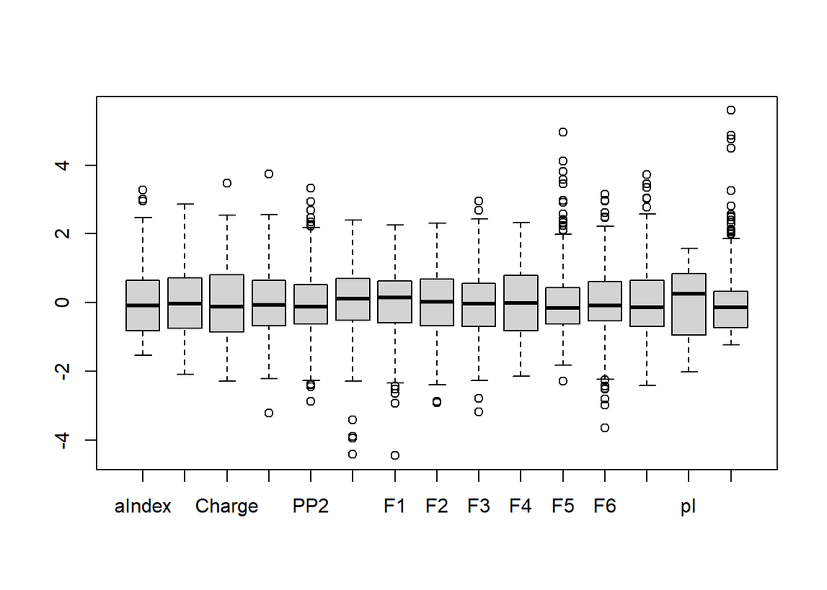

```r
boxplot(pepscale9)
```

## Calculo PCAs y obtención de archivo Excel de rotación

```r
PCApep9 = prcomp(pepscale9)
summary(PCApep9)
```

```
## Importance of components:
##                           PC1    PC2    PC3     PC4     PC5     PC6     PC7
## Standard deviation     2.2089 1.9012 1.3209 1.19841 0.97727 0.90484 0.66913
## Proportion of Variance 0.3253 0.2410 0.1163 0.09575 0.06367 0.05458 0.02985
## Cumulative Proportion  0.3253 0.5663 0.6826 0.77831 0.84198 0.89657 0.92642
##                            PC8    PC9    PC10    PC11    PC12    PC13    PC14
## Standard deviation     0.60966 0.5079 0.39924 0.34895 0.31803 0.23509 0.16281
## Proportion of Variance 0.02478 0.0172 0.01063 0.00812 0.00674 0.00368 0.00177
## Cumulative Proportion  0.95119 0.9684 0.97902 0.98714 0.99388 0.99757 0.99933
##                           PC15
## Standard deviation     0.10008
## Proportion of Variance 0.00067
## Cumulative Proportion  1.00000
```

```r
##write.csv2(PCApep9, "PCApep9.csv")##
```